# Non-Random Resampling: How often do we need to sample wetlands?

Kenneth Anderson

2024-03-07

# Table of contents

1. Selection of Random Days
2. Sampling on single day each week
3. Plots of data
4. Stress Testing the Algorithm
5. Scaling to Monthly Data
6. Comparison of Monthly and Weekly Data
7. Storm Events
8. Load Leaving the wetland
9. Variations on sampling regime
10. Load out with real discharge
11. Comparison of methods

### How often do we need to sample wetlands?

To do this we’re going to use Old Woman Creek Estuary as an example. We will be estimating the phosphorus load entering the system. We’ll get to retention later, but it’s going to be a lot more complicated because there are different frequencies of data at the inflow and outflow of the wetland.

The inflow of the wetland however, has data collected daily for the past 8 years (and another period earlier on, but we’re going to ignore that for now).

Units for this phosphorus data are in ug/L.

```r
setwd("C:/Users/kande120/OneDrive - Kent State University/Phosphorus Budgets/OWC/Data")
owcmasterdata<-read.csv("Master_Nutirent_Dataset_3-7-24.csv")
owcmasterdata$Date<-mdy(owcmasterdata$Date) # tell R that the date is a date

# now lets subset the hell out of this dataset:
owcRL <- subset(owcmasterdata, Project == "RL") # only the retention and load project
owcRLinflow <- subset(owcRL, Site == "BR") # only the inflow at Berlin Road
owcRLinflowrecent <- subset(owcRLinflow, Date >= "2015-01-01") # only from 2015 on
owcDF = owcRLinflowrecent %>% group_by(Site, Date = as.Date(Date,"%Y-%m-%d")) %>% summarise(across(c(TP), mean)) # average any daily TP replicates together
```

Hydrologic data is collected at a USGS gauge at the inlet to the wetland that measures discharge in cubic feet per second. We will use the USGS dataRetrievel package to load it in.

```r
library(dataRetrieval)
# Old Woman Creek at Berlin Rd near Huron OH
siteNumber <- "04199155"
owcInfo <- readNWISsite(siteNumber)
parameterCd <- "00060"

# As a note they have sub-daily data, but we don't need it. We're going to be pairing with daily nutrient data so it's actually super convenient that this code makes the data daily for us!
# Raw daily data:
rawDailyData <- readNWISdv(
  siteNumber, parameterCd,
  "2015-05-05", "2024-01-01")
colnames(rawDailyData)[colnames(rawDailyData) == 'X_00060_00003'] <- 'discharge_cfs'  #rename the discharge column to something meaningful

owcDF <- owcDF %>%
  left_join(y=rawDailyData, by=c("Date")) # merge out 2 datasets

owcBR = owcDF[c("Date","TP","discharge_cfs")] # clean up our dataset so it's just our 3 variables we're interested in
owcBR$discharge_L = owcBR$discharge_cfs * 86400 * 28.3168 # Convert cubic feet/second to liters/day
owcBR$TPmgL = owcBR$TP / 1000 # convert ug/L to mg/L
owcBR$P_lbs = owcBR$discharge_L * owcBR$TPmgL / 453600 # calculate P load and convert to lbs


# we're going to gap fill. It'll make everything easier in terms of coding this out
# first we need to fill in all missing dates with NAs so r doesn't get mad at us:
owcBRcomplete = owcBR %>%
  complete(Date = seq.Date(as.Date("2015-05-04"), max(Date), by = "1 day"))

# Now we need to define the weeks and years in our dataset so r can pick them out
owcBRcomplete$day <- weekdays(owcBRcomplete$Date) # Take out the day of the week
owcBRcomplete$week<-isoweek(owcBRcomplete$Date) # Take out the number for each isoweek.
owcBRcomplete$year<-isoyear(owcBRcomplete$Date) # Create a variable for each isoyear

# then we fill all the gaps with the median value (we're going to use the median for the ENTIRE DATASET)
owcBR_GF = owcBRcomplete %>%
  mutate_if(is.numeric, function(x) ifelse(is.na(x), median(x, na.rm = TRUE), x))
```

As a note to future me we’re using ISO week here so we also need to use iso year in order to make sure that every week is measured separately. The code will get screwy if you don’t do this because then you have replicates because it shoves the wrong samples into the wrong years. This need to be changed when you’re doing months later on. R dates are weird. Iso calender is a whole separate calendar from our normal one so that’s why it gets screwy.

Now we can calculate the annual retention for each year:

```r
# Now we can calculate the annual retention for each year:
trueloading = owcBR_GF %>%
  group_by(year = lubridate::year(Date)) %>%
  summarize(sum_P_true = sum(P_lbs,na.rm = T))
print(trueloading)
```

```
## # A tibble: 9 × 2
##    year sum_P_true
##   <dbl>      <dbl>
## 1  2015      6419.
## 2  2016      8492.
## 3  2017     17717.
## 4  2018     16432.
## 5  2019     13036.
## 6  2020     13841.
## 7  2021      3623.
## 8  2022      6874.
## 9  2023     11539.
```

Now we can start resampling our data:

An important note here is that we don’t want to resample hydrology data, we want to ONLY resample phosphorus data and then APPLY it to the continous hydrology data. The goal is to understand how nutrient sampling frequency affects estimates of retention.

To start our we’ll move from daily sampling to weekly sampling:

```r
# first we make a function to translate our dataset from daily to weekly sampling with a random selection of days being chosen! Then calculate the annual retention for each year within the dataset
weeksample<-function (data){
  # convert to weekly sampling
  working<-data #create dummy data set to operate on
  working <- data %>%
    group_by(week,year) %>% # group by both week and year so this works across different weeks and across different years
    mutate(random_day = sample(day,1)) %>% # sample 1 random day out of the week
    mutate(TP_week = TPmgL[day == random_day]) %>%  # create a value for weekly TP which is the TP value for our randomly selected day
    select(-random_day) # delete our randomly selected day so a new one is chosen for each week
  working$P_lbs_week = working$discharge_L * working$TP_week / 453600 # calculate P load and convert to lbs
  working %>% # take our dataset
    group_by(year) %>% # group so we get a value for each year
    summarize(sum_P = sum(P_lbs_week,na.rm = T)) # calculate the annual retention for each year in the dataframe
}

weeksample(owcBR_GF) # here's an example of a single iteration of weekly sampling
```

```
## # A tibble: 9 × 2
##    year  sum_P
##   <dbl>  <dbl>
## 1  2015  3046.
## 2  2016  2562.
## 3  2017 13712.
## 4  2018 11939.
## 5  2019  5806.
## 6  2020  7974.
## 7  2021  3188.
## 8  2022  4136.
## 9  2023  6706.
```

Now we can replicate this function 1000 times in order to get a wide spread of what our estimates will look like as we standardize our data to weekly samples instead of daily.

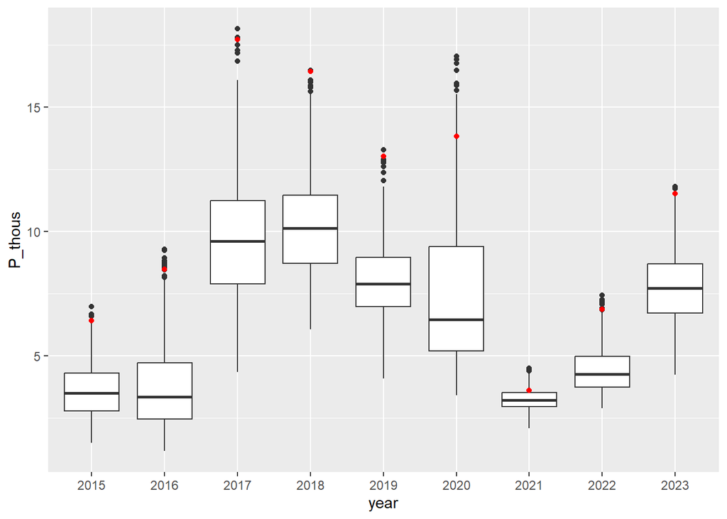

```r
# Now we replicate this function a couple thousand times, and add all the results to a dataframe.
bigdf=replicate(1000, weeksample(owcBR_GF),simplify=FALSE)
# combine all our dataframes together
bigdf_combined <- map_dfr(bigdf, bind_rows, .id = "tib")
bigdf_combined$year = as.factor(bigdf_combined$year)
trueloading$year = as.factor(trueloading$year)
bigdf_combined$P_thous = bigdf_combined$sum_P / 1000
trueloading$P_thous_true = trueloading$sum_P_true / 1000

# lets plot it out:
ggplot() +
  geom_boxplot(data = bigdf_combined, aes(x=year, y=P_thous)) +
  geom_point(data = trueloading, aes (x=year, y=P_thous_true),color='red')
```

You can see there is across the board an underestimate of true values when converting from daily to weekly sampling. Likely this is because high concentrations are irregular and spread out, so random days are not likely to catch the big peaks in P concentrations on certain days with high loading.

Let’s take out time and calculate some metrics of this model including the bias, the imprecision, and the relative root mean square error!

```r
bigdf_combined = bigdf_combined %>% left_join(y=trueloading, by=c("year")) # add the true values to the dataset so we can compute uncertainty!
bigdf_combined$e = (bigdf_combined$P_thous - bigdf_combined$P_thous_true)/ bigdf_combined$P_thous_true # calculate the error associated with each budget

dfe = bigdf_combined %>%
  group_by(year) %>%
  summarise(med = median(e)) # this is a measure of the Bias. Negative number indicates a consistent negative bias (here it ranges between years from -10 to -60%)
print(dfe)
```

```
## # A tibble: 9 × 2
##   year     med
##   <fct>  <dbl>
## 1 2015  -0.452
## 2 2016  -0.605
## 3 2017  -0.457
## 4 2018  -0.383
## 5 2019  -0.394
## 6 2020  -0.533
## 7 2021  -0.107
## 8 2022  -0.380
## 9 2023  -0.331
```

```r
mean(dfe$med)
```

```
## [1] -0.4046069
```

```r
df90 = bigdf_combined %>%
  group_by(year) %>%
  summarise("value90" = quantile(e, probs=0.9, na.rm=TRUE)) # calculate the 90th percentile for each year
df10 = bigdf_combined %>%
  group_by(year) %>%
  summarise("value10" = quantile(e, probs=0.1, na.rm=TRUE)) # calculate the 10th percentile for each year
Imprecisiondf = df90 %>% left_join(y=df10, by=c("year")) # Merge the 90th and 10th percentile
Imprecisiondf$imprecision = Imprecisiondf$value90-Imprecisiondf$value10
print(Imprecisiondf) # values below 20% are acceptable. This indicates that there's high variation in uncertainty of our estimation.
```

```
## # A tibble: 9 × 4
##   year  value90 value10 imprecision
##   <fct>   <dbl>   <dbl>       <dbl>
## 1 2015  -0.223   -0.676       0.454
## 2 2016  -0.277   -0.765       0.488
## 3 2017  -0.269   -0.623       0.354
## 4 2018  -0.218   -0.531       0.313
## 5 2019  -0.235   -0.533       0.298
## 6 2020  -0.141   -0.664       0.523
## 7 2021   0.0448  -0.241       0.286
## 8 2022  -0.180   -0.497       0.317
## 9 2023  -0.164   -0.480       0.316
```

```r
mean(Imprecisiondf$imprecision) # the average
```

```
## [1] 0.3720092
```

Now we’re going to start a new dataframe to contain the bias and imprecision of each method so we can plot it all out later!

```r
weeklystats <- dfe %>%
  left_join(y=Imprecisiondf, by=c("year"))%>% # merge the bias and imprecision data
  mutate(method = "weekly")

methodstats = weeklystats[,c("year","med","imprecision","method")]
```

## How about a more practical variation of this: choosing individual days

We can also look at how sampling on a specific day of the week changes results. This method keeps a standard distance between samples, but gives us less insight into the amount of potential variability with only 7 possible combinations.

```r
## Alternate method using SPECIFIC days of the week:
# create a function to strip out each variation with a certain day of the week being sampled
weekdayssamp<-function (data){
  # convert to weekly sampling
  weekdays <- c("Monday","Tuesday","Wednesday","Thursday","Friday","Saturday","Sunday")
  working<-data #create dummy data set to operate on
  output<-data.frame(year=integer(0), #create empty data frame to put our output variables in
                     sum_P=integer(0))
  while (length(weekdays) > 1){ #while there's still more days of the week
    working <- data %>%
      group_by(week,year) %>% # group by both week and year so this works across different weeks and across different years
      mutate(TP_week = ifelse(is.na(TPmgL[day == weekdays[1]]), yes = mean(TPmgL), no = TPmgL[day == weekdays[1]] ))
    working$P_lbs_week = working$discharge_L * working$TP_week / 453600 # calculate P load and convert to lbs
    out <- working %>% # take our dataset
      group_by(year) %>% # group so we get a value for each year
      summarize(sum_P = sum(P_lbs_week,na.rm = T)) # calculate the annual retention for each year in the dataframe
    #add a conditional so that if there's missing data, it's not included in output
    output<-rbind(output, out) #append the stats to the output data frame
    weekdays<-weekdays[-1] #cut out the first year of the remaining data + repeat
  }
  return(output)#output the data frame
}

weeklysamp = weekdayssamp(owcBR_GF)
```

Now we can plot out our results as compared to the true values calculated from the entire dataset

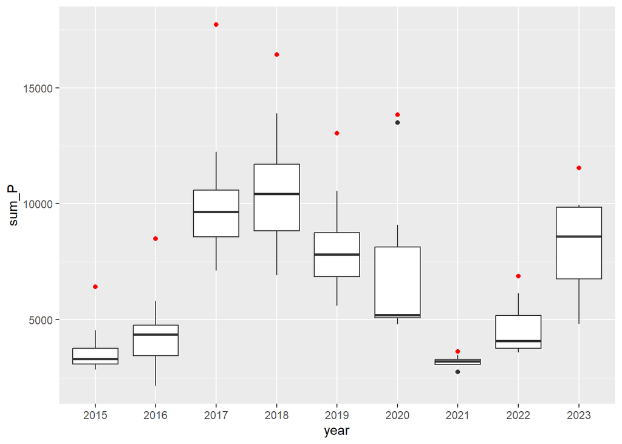

```r
# let's look at the difference from the true value instead.
trueloading$sum_P_true = trueloading$sum_P_true
trueloading$year = as.factor(trueloading$year)
weeklysamp$year = as.factor(weeklysamp$year)


# plot out the range from all 7 weekdays along with the true value (in red):
ggplot() +
  geom_boxplot(data = weeklysamp, aes(x=year, y=sum_P)) +
  geom_point(data = trueloading, aes (x=year, y=sum_P_true),color='red')
```

## Plotting the data

Lets take a look at phosphorus concentrations to see if we can explain this:

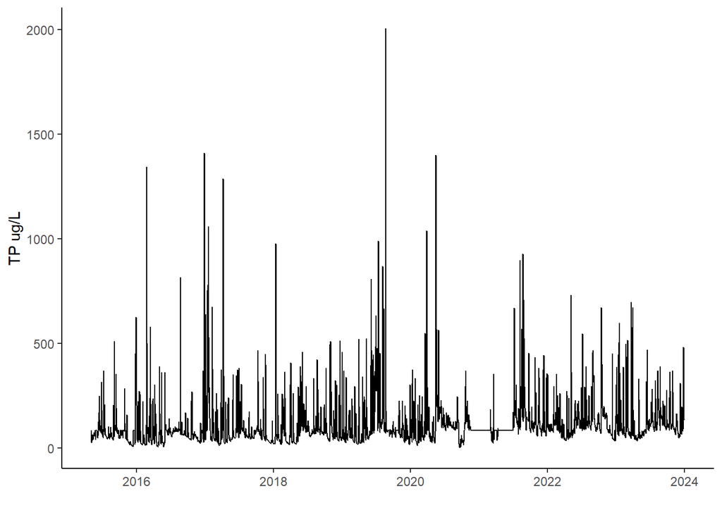

```r
ggplot(owcBR_GF, aes(x=Date, y=TP)) +
  geom_line() +
  xlab("") + ylab("TP ug/L")+theme_classic()
```

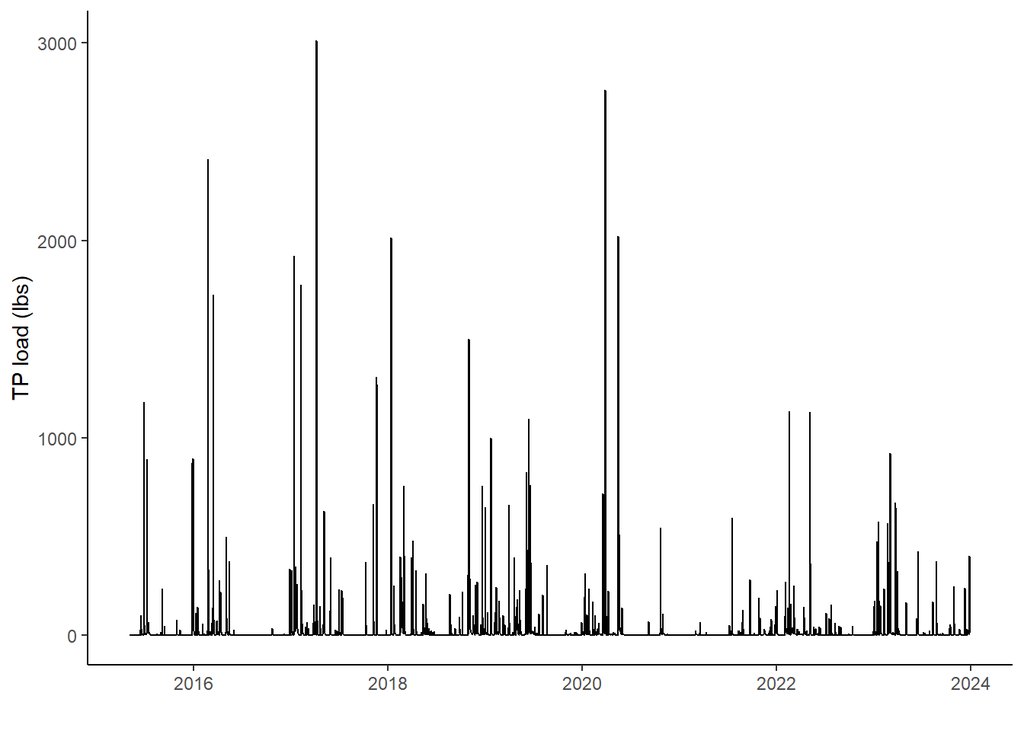

```r
ggplot(owcBR_GF, aes(x=Date, y=P_lbs)) +
  geom_line() +
  xlab("") + ylab("TP load (lbs)")+theme_classic()
```

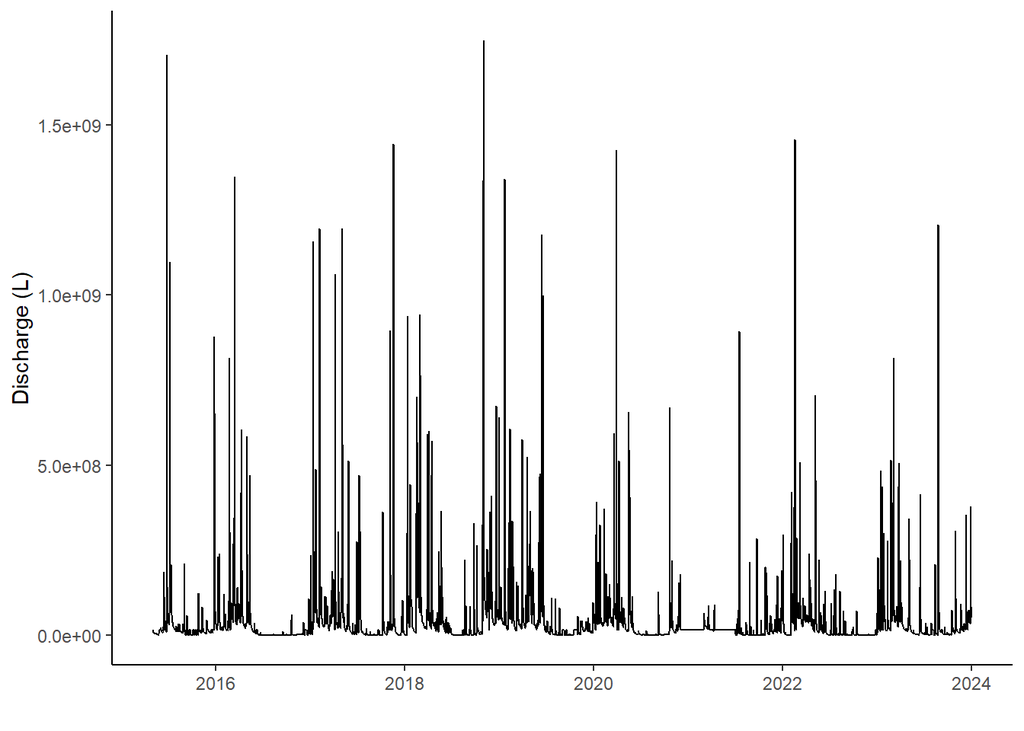

```r
ggplot(owcBR_GF, aes(x=Date, y=discharge_L)) +
  geom_line() +
  xlab("") + ylab("Discharge (L)")+theme_classic()
```

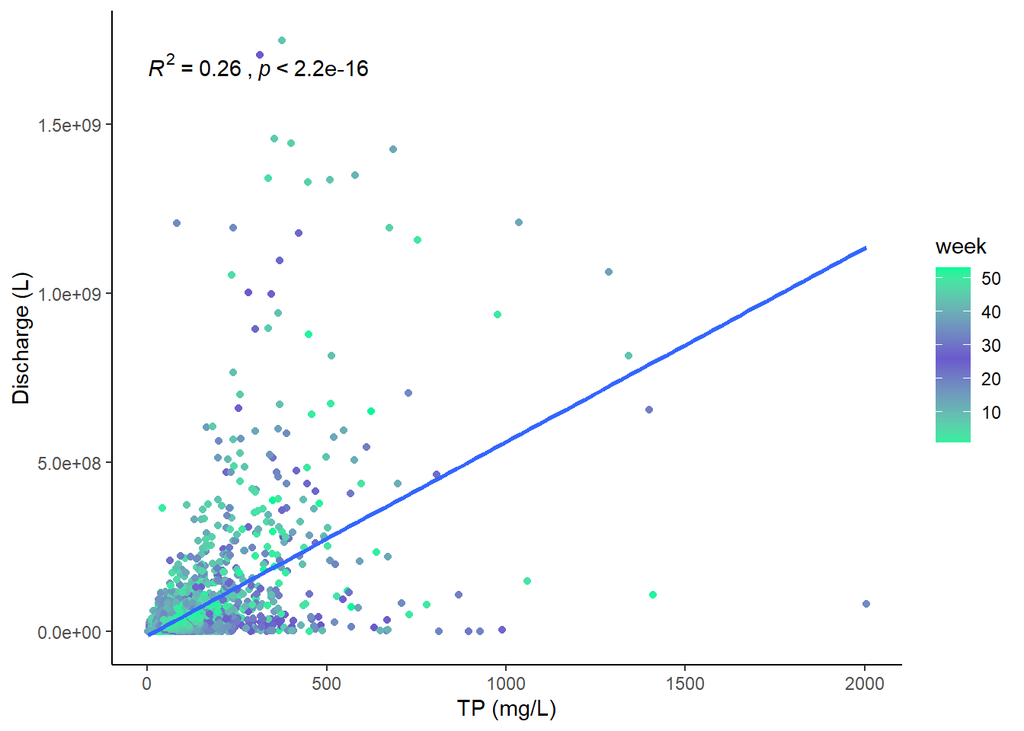

```r
mid<-26
library(ggpubr)
ggplot(owcBR_GF, aes(x=TP, y=discharge_L, color = week)) +
  geom_point() +
  xlab("TP (mg/L)") + ylab("Discharge (L)")+
  scale_color_gradient2(midpoint=mid, low="mediumspringgreen", mid="slateblue", high="mediumspringgreen")+theme_classic()+
  stat_cor(method = "pearson",aes(label = paste(..rr.label.., ..p.label.., sep = "~`,`~")))+ geom_smooth(method=lm, se=FALSE, fullrange=F)
```

If this is real… I think what’s happening is that the really spiky changes in P concentration is what’s driving this pattern.

## Lets stress test this algorithm

Lets start out by seeing if we’re able to modify the algorithm with our real data and only pick out the highest value of phosphorus for each week. This should produce the highest possible result and overestimate phosphorus retention (but based on our previous model, not by that much).

```r
# make a function that does the same as above but instead of selecting a random phosphorus concentration selects the maximum for the week

maxsample<-function (data){
  # convert to weekly sampling
  working<-data #create dummy data set to operate on
  working <- data %>%
    group_by(week,year) %>% # group by both week and year so this works across different weeks and across different years
    mutate(max_day =  ifelse(all(is.na(TPmgL)), yes = NA, no = sample(day[which.max(TPmgL)]))) %>% # sample the day with the highest TP value
    mutate(TP_week = TPmgL[day == max_day]) %>%  # select the maximum TP value
    select(-max_day) # delete our maximum day so a new one is chosen for each week
  working$P_lbs_week = working$discharge_L * working$TP_week / 453600 # calculate P load and convert to lbs
  working %>% # take our dataset
    group_by(year) %>% # group so we get a value for each year
    summarize(sum_P = sum(P_lbs_week,na.rm = T)) # calculate the annual retention for each year in the dataframe
}

maxvalues = maxsample(owcBR_GF) # run the code
maxvalues$year= as.factor(maxvalues$year)

trueloading1 = trueloading[c("year","sum_P_true")] # clean up our dataset so it's just our 3 variables we're interested in
trueloading1$year= as.factor(trueloading1$year)

comparison <- trueloading1 %>%
  left_join(y=,maxvalues, by=c("year")) # merge out 2 datasets

print(comparison) # compare to the true loading
```

```
## # A tibble: 9 × 3
##   year  sum_P_true  sum_P
##   <fct>      <dbl>  <dbl>
## 1 2015       6419.  7972.
## 2 2016       8492. 12041.
## 3 2017      17717. 23491.
## 4 2018      16432. 22605.
## 5 2019      13036. 18710.
## 6 2020      13841. 19741.
## 7 2021       3623.  5578.
## 8 2022       6874.  8973.
## 9 2023      11539. 16980.
```

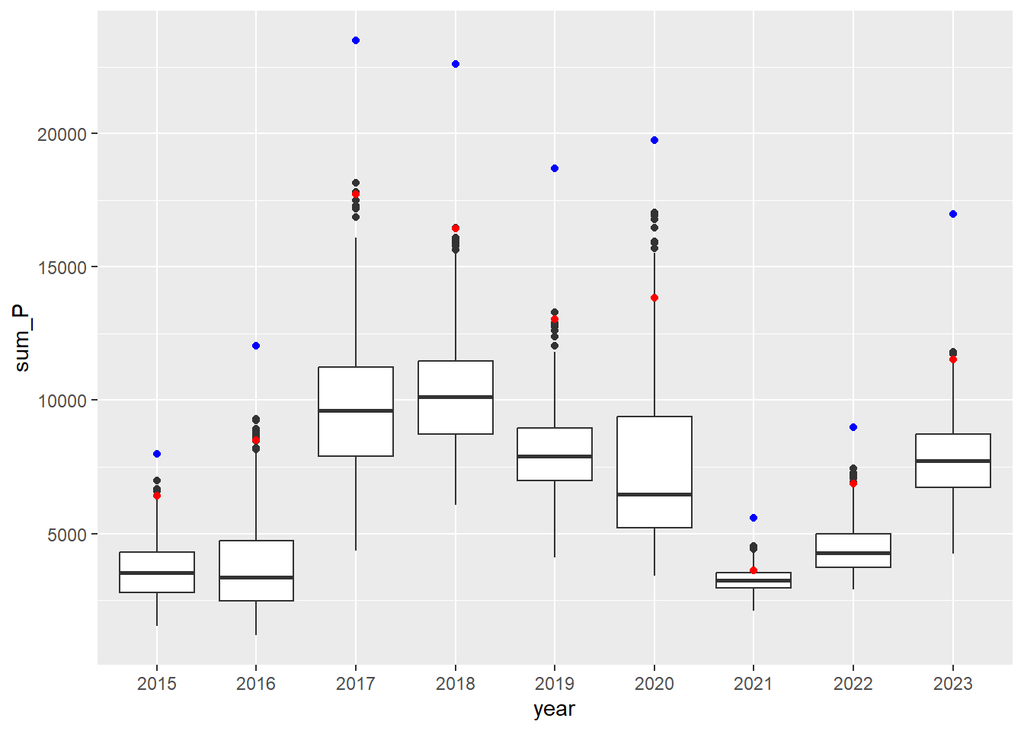

```r
# plot it out!
ggplot() +
  geom_boxplot(data = bigdf_combined, aes(x=year, y=sum_P)) +
  geom_point(data = trueloading1, aes (x=year, y=sum_P_true),color='red')+
  geom_point(data = maxvalues, aes (x=year, y=sum_P),color='blue')
```

We see that the maximum value always over predicts, BUT it over predicts MORE than any of our values from our random re-sampling… This is likely because it’s just unlikely to select the max values for every week. I think there’s 7^52 (8.812479e+43) possible combinations for each year so it’s not unlikely that we wouldn’t reach the maximum value.

Now we’re going to make some fake data to run the actual algorithm on:

```r
library(truncnorm)
n <- 1460
fakedata <- data.frame(
  Date = seq(as.Date("2015-01-01"), by = "day", length.out = n),
  discharge_L = rtruncnorm(n=n, a=0, b=852089387, mean=52089387, sd=40000000),
  TPmgL = rtruncnorm(n=n, a=0, b=5, mean=1, sd=1.5)
)
fakedata$P_lbs = fakedata$discharge_L * fakedata$TPmgL / 453600 # calculate P load and convert to lbs

# Now we need to define the weeks and years in our dataset so r can pick them out
fakedata$day <- weekdays(fakedata$Date) # Take out the day of the week
fakedata$week<-isoweek(fakedata$Date) # Take out the number for each week.
fakedata$year<-isoyear(fakedata$Date) # Create a variable for each year

# Now we can calculate the annual retention for each year:
fakeloading = fakedata %>%
  group_by(year = lubridate::year(Date)) %>%
  summarize(sum_P = sum(P_lbs,na.rm = T))
print(fakeloading)
```

```
## # A tibble: 4 × 2
##    year  sum_P
##   <dbl>  <dbl>
## 1  2015 84074.
## 2  2016 79836.
## 3  2017 77177.
## 4  2018 76138.
```

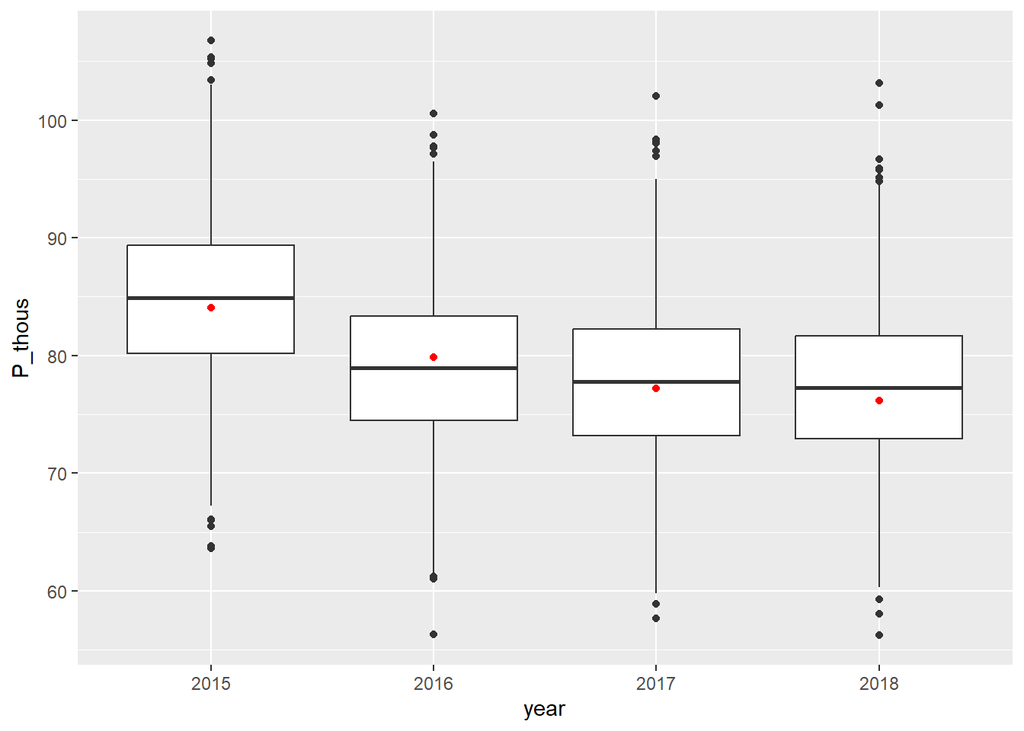

```r
# Now we run it and combine all the results into a dataframe
bigfake=replicate(1000, weeksample(fakedata),simplify=FALSE)
# combine all our dataframes together
bigfake_combined <- map_dfr(bigfake, bind_rows, .id = "tib")
bigfake_combined$year = as.factor(bigfake_combined$year)
fakeloading$year = as.factor(fakeloading$year)
bigfake_combined$P_thous = bigfake_combined$sum_P / 1000
fakeloading$P_thous_true = fakeloading$sum_P / 1000
# lets plot it out:
ggplot() +
  geom_boxplot(data = bigfake_combined, aes(x=year, y=P_thous)) +
  geom_point(data = fakeloading, aes (x=year, y=P_thous_true),color='red')
```

IT’S WORKING!!

## Lets see how monthly sampling does!

```r
# first need to pick up the individual months:
owcBR_GF$month<-month(owcBRcomplete$Date) # Create a variable for each month
owcBR_GF$daynum<-day(owcBRcomplete$Date) # Create a variable for each day of the month
owcBR_GF$year<-year(owcBRcomplete$Date) # Create a variable for each year (but this time NOT iso year because that makes everything all screwy)

# new function but this time selecting a random day of each MONTH
monthsample<-function (data){
  # convert to monthly sampling
  working<-data #create dummy data set to operate on
  working <- data %>%
    group_by(month,year) %>% # group by both month and year so this works across different months and across different years
    mutate(random_day = sample(daynum,1)) %>% # sample 1 random day out of the month
    mutate(TP_month = TPmgL[daynum == random_day]) %>%  # create a value for weekly TP which is the TP value for our randomly selected day
    select(-random_day) # delete our randomly selected day so a new one is chosen for each month
  working$P_lbs_week = working$discharge_L * working$TP_month / 453600 # calculate P load and convert to lbs
  working %>% # take our dataset
    group_by(year) %>% # group so we get a value for each year
    summarize(sum_P = sum(P_lbs_week,na.rm = T)) # calculate the annual retention for each year in the dataframe
}

monthsample(owcBR_GF) # here's an example of a single iteration of monthly sampling
```

```
## # A tibble: 9 × 2
##    year sum_P
##   <dbl> <dbl>
## 1  2015 2174.
## 2  2016 1472.
## 3  2017 4096.
## 4  2018 6955.
## 5  2019 4239.
## 6  2020 6245.
## 7  2021 3355.
## 8  2022 3475.
## 9  2023 5142.
```

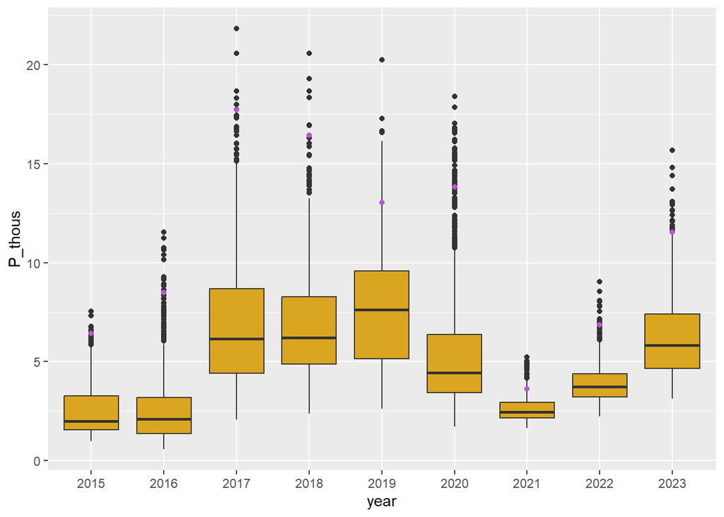

```r
# Now we replicate this function a couple thousand times, and add all the results to a dataframe.
bigdfm=replicate(1000, monthsample(owcBR_GF),simplify=FALSE)
# combine all our dataframes together
bigdfm_combined <- map_dfr(bigdfm, bind_rows, .id = "tib")
bigdfm_combined$year = as.factor(bigdfm_combined$year)
trueloading$year = as.factor(trueloading$year)
bigdfm_combined$P_thous = bigdfm_combined$sum_P / 1000
trueloading$P_thous_true = trueloading$sum_P_true / 1000
maxvalues$P_thous = maxvalues$sum_P / 1000

ggplot() +
  geom_boxplot(data = bigdfm_combined, aes(x=year, y=P_thous), fill = 'goldenrod') + # monthly sampling
  geom_point(data = trueloading, aes (x=year, y=P_thous_true),color='mediumorchid') # daily sampling
```

A notable differences is the higher spread/abundance of outliers in monthly as compared to weekly sampling.

Let’s look at the maximums for monthly sampling and then plot everything out:

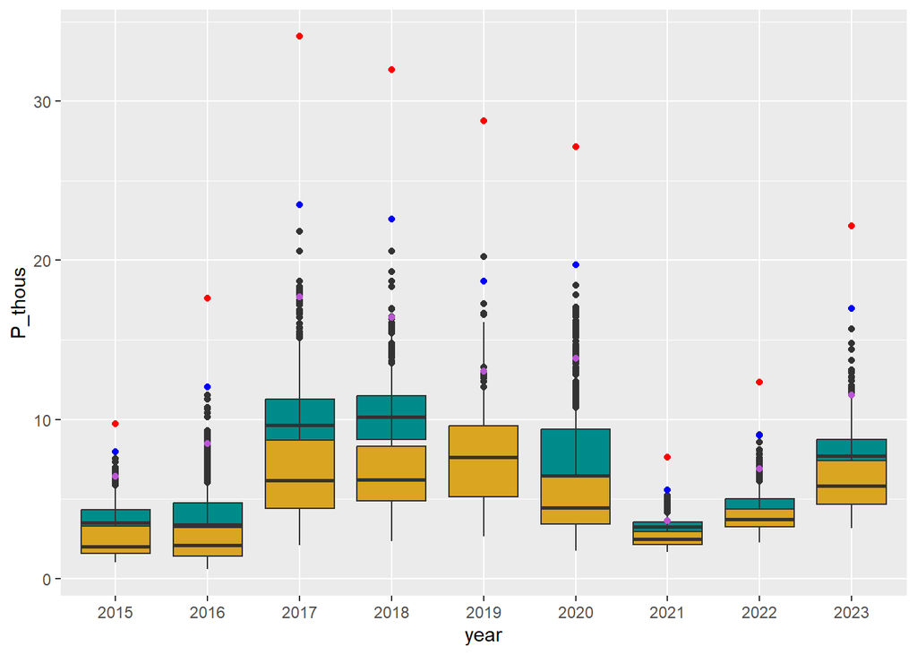

```r
maxsamplem<-function (data){
  # convert to weekly sampling
  working<-data #create dummy data set to operate on
  working <- data %>%
    group_by(month,year) %>% # group by both month and year so this works across different months and across different years
    mutate(max_day =  daynum[which.max(TPmgL)]) %>% # sample the day with the highest TP value
    mutate(TP_month = TPmgL[daynum == max_day]) %>%  # select the maximum TP value
    select(-max_day) # delete our maximum day so a new one is chosen for each month
  working$P_lbs_month = working$discharge_L * working$TP_month / 453600 # calculate P load and convert to lbs
  working %>% # take our dataset
    group_by(year) %>% # group so we get a value for each year
    summarize(sum_P = sum(P_lbs_month,na.rm = T)) # calculate the annual retention for each year in the dataframe
}
maxvaluesm = maxsamplem(owcBR_GF)
maxvaluesm$P_thous = maxvaluesm$sum_P / 1000
maxvaluesm$year = as.factor(maxvaluesm$year)

# lets plot everything out together:
ggplot() +
  geom_boxplot(data = bigdf_combined, aes(x=year, y=P_thous), fill = 'darkcyan') + # weekly sampling
  geom_boxplot(data = bigdfm_combined, aes(x=year, y=P_thous), fill = 'goldenrod') + # monthly sampling
  geom_point(data = trueloading, aes (x=year, y=P_thous_true),color='mediumorchid')+ # daily sampling
  geom_point(data = maxvalues, aes (x=year, y=P_thous),color='blue')+ # maximum values for taking the max number each WEEK
  geom_point(data = maxvaluesm, aes (x=year, y=P_thous),color='red') # maximum values for taking the max number each MONTH
```

We see that monthly sampling has greater underestimates than we get for weekly sampling! BUT there are a lot more outliers than we get at weekly sampling! It’s more likely to underestimate AND more likely to overestimate (albeit only as outliers).

Let’s take out time and calculate some metrics of this model including the bias, the imprecision, and the relative root mean square error!

```r
bigdfm_combined = bigdfm_combined %>% left_join(y=trueloading, by=c("year")) # add the true values to the dataset so we can compute uncertainty!
bigdfm_combined$e = (bigdfm_combined$P_thous - bigdfm_combined$P_thous_true)/ bigdfm_combined$P_thous_true # calculate the error associated with each budget

dfme = bigdfm_combined %>%
  group_by(year) %>%
  summarise(med = median(e)) # this is a measure of the Bias. Negative number indicates a consistent negative bias (here it ranges between years from -10 to -60%)
print(dfme)
```

```
## # A tibble: 9 × 2
##   year     med
##   <fct>  <dbl>
## 1 2015  -0.690
## 2 2016  -0.753
## 3 2017  -0.653
## 4 2018  -0.622
## 5 2019  -0.416
## 6 2020  -0.680
## 7 2021  -0.320
## 8 2022  -0.458
## 9 2023  -0.496
```

```r
mean(dfme$med)
```

```
## [1] -0.5651473
```

```r
dfm90 = bigdfm_combined %>%
  group_by(year) %>%
  summarise("value90" = quantile(e, probs=0.9, na.rm=TRUE)) # calculate the 90th percentile for each year
dfm10 = bigdfm_combined %>%
  group_by(year) %>%
  summarise("value10" = quantile(e, probs=0.1, na.rm=TRUE)) # calculate the 10th percentile for each year
Imprecisionmdf = dfm90 %>% left_join(y=dfm10, by=c("year")) # Merge the 90th and 10th percentile
Imprecisionmdf$imprecision = Imprecisionmdf$value90-Imprecisionmdf$value10
print(Imprecisionmdf) # values below 20% are acceptable. This indicates that there's high variation in uncertainty of our estimation.
```

```
## # A tibble: 9 × 4
##   year  value90 value10 imprecision
##   <fct>   <dbl>   <dbl>       <dbl>
## 1 2015  -0.305   -0.788       0.484
## 2 2016  -0.457   -0.884       0.427
## 3 2017  -0.328   -0.804       0.476
## 4 2018  -0.362   -0.757       0.395
## 5 2019  -0.106   -0.694       0.587
## 6 2020  -0.277   -0.800       0.523
## 7 2021  -0.0440  -0.467       0.423
## 8 2022  -0.215   -0.572       0.357
## 9 2023  -0.198   -0.663       0.464
```

```r
mean(Imprecisionmdf$imprecision) # the average
```

```
## [1] 0.459779
```

```r
# now to add these to our running dataframe of methodstats:
monthlystats <- dfme %>%
  left_join(y=Imprecisionmdf, by=c("year"))%>% # merge the bias and imprecision data
  mutate(method = "monthly")
monthlystats = monthlystats[,c("year","med","imprecision","method")] # get rid of the excess columns

methodstats = rbind(methodstats,monthlystats) # add on to our running dataframe
```

## Lets try picking out storm events to estimate loading instead!

We’re going to go with the OWC storm event standards and consider all days with flow > 25 CFS to be storm events.

```r
stormflow = 25 * 86400 * 28.3168 # convert 25 CFS to liters / day
```

Now we’re going to make a function that will sample monthly AND sample all storm events with flow > 25 CFS:

```r
# new function but this time selecting a random day of each MONTH and including ALL storm sampling events
monthstormsample<-function (data){
  # convert to monthly sampling
  working<-data #create dummy data set to operate on
  working <- data %>%
    group_by(month,year) %>% # group by both month and year so this works across different months and across different years
    mutate(random_day = sample(daynum,1)) %>% # sample 1 random day out of the month
    mutate(TP_month = TPmgL[daynum == random_day]) %>%  # create a value for weekly TP which is the TP value for our randomly selected day
    select(-random_day) # delete our randomly selected day so a new one is chosen for each month
  working$TP_month = ifelse(working$discharge_cfs>25, working$TPmgL, working$TP_month)
  working$P_lbs_week = working$discharge_L * working$TP_month / 453600 # calculate P load and convert to lbs
  working %>% # take our dataset
    group_by(year) %>% # group so we get a value for each year
    summarize(sum_P = sum(P_lbs_week,na.rm = T)) # calculate the annual retention for each year in the dataframe
}
monthstormsample(owcBR_GF)
```

```
## # A tibble: 9 × 2
##    year  sum_P
##   <dbl>  <dbl>
## 1  2015  6462.
## 2  2016  8400.
## 3  2017 19172.
## 4  2018 16246.
## 5  2019 13249.
## 6  2020 14036.
## 7  2021  3616.
## 8  2022  6945.
## 9  2023 11741.
```

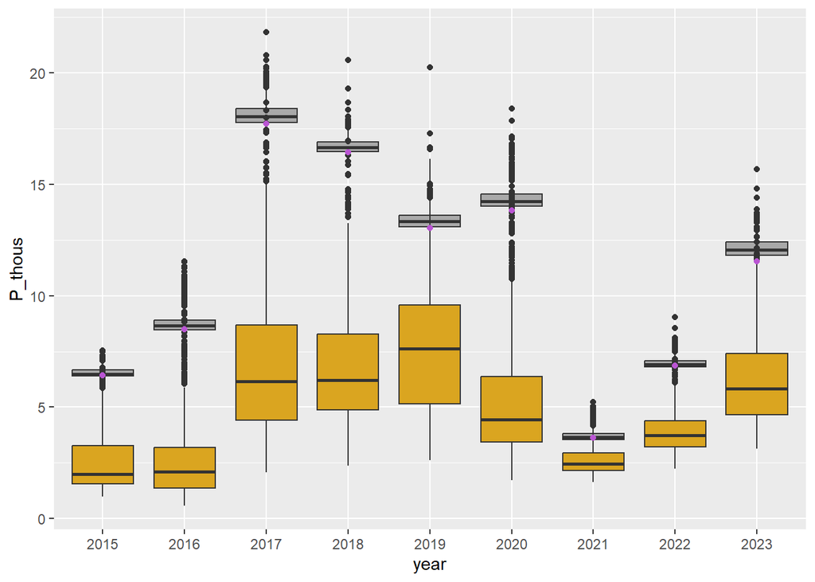

```r
# Now we replicate this function a couple thousand times, and add all the results to a dataframe.
bigdfmstorm=replicate(1000, monthstormsample(owcBR_GF),simplify=FALSE)
# combine all our dataframes together
bigdfmstorm_combined <- map_dfr(bigdfmstorm, bind_rows, .id = "tib")
bigdfmstorm_combined$year = as.factor(bigdfmstorm_combined$year)
bigdfmstorm_combined$P_thous = bigdfmstorm_combined$sum_P / 1000


# lets plot everything out together:
ggplot() +
  geom_boxplot(data = bigdfmstorm_combined, aes(x=year, y=P_thous), fill = 'darkgrey') + # monthly + storm sampling
  geom_boxplot(data = bigdfm_combined, aes(x=year, y=P_thous), fill = 'goldenrod') + # monthly sampling
  geom_point(data = trueloading, aes (x=year, y=P_thous_true),color='mediumorchid') # daily sampling
```

Capturing all the storm events makes it pretty much right on the money (a little bit of an overestimate some years).  
Now lets see if we can try with varying numbers of storm events!

```r
# First lets look at how many storm events there are each year!

owcBR_GF %>%
  group_by(year) %>%
  summarize(discharge = sum(discharge_cfs > 25))
```

```
## # A tibble: 9 × 2
##    year discharge
##   <dbl>     <int>
## 1  2015        27
## 2  2016        50
## 3  2017        78
## 4  2018       109
## 5  2019        85
## 6  2020        61
## 7  2021        25
## 8  2022        54
## 9  2023        67
```

There are a LOT of storm events when we’re considering 25 as our cutoff for storm flow

```r
owcBR_GF %>%
  group_by(year) %>%
  summarize(discharge = sum(discharge_cfs > 100))
```

```
## # A tibble: 9 × 2
##    year discharge
##   <dbl>     <int>
## 1  2015         6
## 2  2016         9
## 3  2017        20
## 4  2018        34
## 5  2019        21
## 6  2020        14
## 7  2021         2
## 8  2022        11
## 9  2023        20
```

A more reasonable number when we scale that up to 100 cfs as our cutoff!

```r
# new function but this time selecting a random day of each MONTH and including ALL storm sampling events
monthstormsample<-function (data){
  # convert to monthly sampling
  working<-data #create dummy data set to operate on
  working <- data %>%
    group_by(month,year) %>% # group by both month and year so this works across different months and across different years
    mutate(random_day = sample(daynum,1)) %>% # sample 1 random day out of the month
    mutate(TP_month = TPmgL[daynum == random_day]) %>%  # create a value for weekly TP which is the TP value for our randomly selected day
    select(-random_day) # delete our randomly selected day so a new one is chosen for each month
  working$TP_month = ifelse(working$discharge_cfs>100, working$TPmgL, working$TP_month)
  working$P_lbs_week = working$discharge_L * working$TP_month / 453600 # calculate P load and convert to lbs
  working %>% # take our dataset
    group_by(year) %>% # group so we get a value for each year
    summarize(sum_P = sum(P_lbs_week,na.rm = T)) # calculate the annual retention for each year in the dataframe
}
monthstormsample(owcBR_GF)
```

```
## # A tibble: 9 × 2
##    year  sum_P
##   <dbl>  <dbl>
## 1  2015  5798.
## 2  2016  7873.
## 3  2017 19333.
## 4  2018 16629.
## 5  2019 12334.
## 6  2020 12899.
## 7  2021  3705.
## 8  2022  7156.
## 9  2023 10564.
```

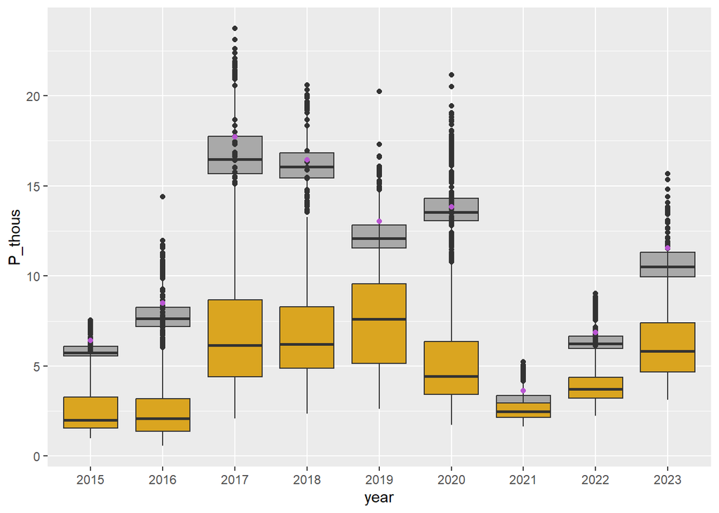

```r
# Now we replicate this function a couple thousand times, and add all the results to a dataframe.
bigdfmstorms=replicate(1000, monthstormsample(owcBR_GF),simplify=FALSE)
# combine all our dataframes together
bigdfmstorms_combined <- map_dfr(bigdfmstorms, bind_rows, .id = "tib")
bigdfmstorms_combined$year = as.factor(bigdfmstorms_combined$year)
bigdfmstorms_combined$P_thous = bigdfmstorms_combined$sum_P / 1000


# lets plot everything out together:
ggplot() +
  geom_boxplot(data = bigdfmstorms_combined, aes(x=year, y=P_thous), fill = 'darkgrey') + # monthly + storm sampling
  geom_boxplot(data = bigdfm_combined, aes(x=year, y=P_thous), fill = 'goldenrod') + # monthly sampling
  geom_point(data = trueloading, aes (x=year, y=P_thous_true),color='mediumorchid') # daily sampling
```

```r
# lets calculate our bias metrics
bigdfmstorms_combined = bigdfmstorms_combined %>% left_join(y=trueloading, by=c("year")) # add the true values to the dataset so we can compute uncertainty!
bigdfmstorms_combined$e = (bigdfmstorms_combined$P_thous - bigdfmstorms_combined$P_thous_true)/ bigdfmstorms_combined$P_thous_true # calculate the error associated with each budget

dfmse = bigdfmstorms_combined %>%
  group_by(year) %>%
  summarise(med = median(e)) # this is a measure of the Bias. Negative number indicates a consistent negative bias (here it ranges between years from -10 to -60%)
print(dfmse)
```

```
## # A tibble: 9 × 2
##   year      med
##   <fct>   <dbl>
## 1 2015  -0.108
## 2 2016  -0.101
## 3 2017  -0.0700
## 4 2018  -0.0219
## 5 2019  -0.0725
## 6 2020  -0.0220
## 7 2021  -0.203
## 8 2022  -0.0909
## 9 2023  -0.0889
```

```r
mean(dfmse$med)
```

```
## [1] -0.086518
```

```r
dfms90 = bigdfmstorms_combined %>%
  group_by(year) %>%
  summarise("value90" = quantile(e, probs=0.9, na.rm=TRUE)) # calculate the 90th percentile for each year
dfms10 = bigdfmstorms_combined %>%
  group_by(year) %>%
  summarise("value10" = quantile(e, probs=0.1, na.rm=TRUE)) # calculate the 10th percentile for each year
Imprecisionmdfs = dfms90 %>% left_join(y=dfms10, by=c("year")) # Merge the 90th and 10th percentile
Imprecisionmdfs$imprecision = Imprecisionmdfs$value90-Imprecisionmdfs$value10
print(Imprecisionmdfs) # values below 20% are acceptable. This indicates that there's high variation in uncertainty of our estimation.
```

```
## # A tibble: 9 × 4
##   year   value90 value10 imprecision
##   <fct>    <dbl>   <dbl>       <dbl>
## 1 2015  -0.00576 -0.146        0.140
## 2 2016   0.0607  -0.188        0.249
## 3 2017   0.0739  -0.143        0.216
## 4 2018   0.0708  -0.0857       0.157
## 5 2019   0.0445  -0.149        0.194
## 6 2020   0.128   -0.0798       0.208
## 7 2021   0.0330  -0.317        0.350
## 8 2022   0.0261  -0.159        0.185
## 9 2023   0.0428  -0.162        0.205
```

```r
mean(Imprecisionmdfs$imprecision) # the average
```

```
## [1] 0.2115024
```

```r
# now to add these to our running dataframe of methodstats:
allstormstats <- dfmse %>%
  left_join(y=Imprecisionmdfs, by=c("year"))%>% # merge the bias and imprecision data
  mutate(method = "all_storms")
allstormstats = allstormstats[,c("year","med","imprecision","method")] # get rid of the excess columns

methodstats = rbind(methodstats,allstormstats) # add on to our running dataframe
```

AND we see that at 100 cfs as our storm event cutoff we still have a pretty good estimate of loading! (there’s a slight underestimate).

So NOW our goal is to make a new function to look at how many storms we need to sample to get an accurate loading budget.

```r
# new function but this time selecting a random day of each MONTH and including ALL storm sampling events
subsetstormsample<-function (data){
  # convert to monthly sampling
  working<-owcBR_GF #create dummy data set to operate on
  working <- owcBR_GF %>%
    group_by(month,year) %>% # group by both month and year so this works across different months and across different years
    mutate(random_day = sample(daynum,1)) %>% # sample 1 random day out of the month
    mutate(TP_month = TPmgL[daynum == random_day]) %>%  # create a value for weekly TP which is the TP value for our randomly selected day
    select(-random_day) # delete our randomly selected day so a new one is chosen for each month
  working <- working %>%
    mutate(stormcon = ifelse(discharge_cfs>100, TPmgL, 'NA'))
  working$stormcon = as.numeric(working$stormcon)
  working <- working %>%
    group_by(year)%>%
    mutate(stormPav = mean(sample(working$stormcon[complete.cases(working$stormcon)],5))) # sample 5 storms and use them to compute an average stormflow concentration for the year
  working <- working %>%
    group_by(month,year)%>%
    mutate(stormPcon = ifelse(discharge_cfs>100, stormPav, TP_month)) # replace all storm values with the average storm concentration for the year
  working$P_lbs_storm = working$discharge_L * working$stormPcon / 453600 # calculate P load and convert to lbs
  working %>% # take our dataset
    group_by(year) %>% # group so we get a value for each year
    summarize(sum_P = sum(P_lbs_storm,na.rm = T)) # calculate the annual retention for each year in the dataframe
}

suppressWarnings({subsetstormsample(owcBR_GF)})
```

```
## # A tibble: 9 × 2
##    year  sum_P
##   <dbl>  <dbl>
## 1  2015  3803.
## 2  2016  7015.
## 3  2017 12258.
## 4  2018 12074.
## 5  2019 14762.
## 6  2020  8601.
## 7  2021  3341.
## 8  2022  7168.
## 9  2023  9319.
```

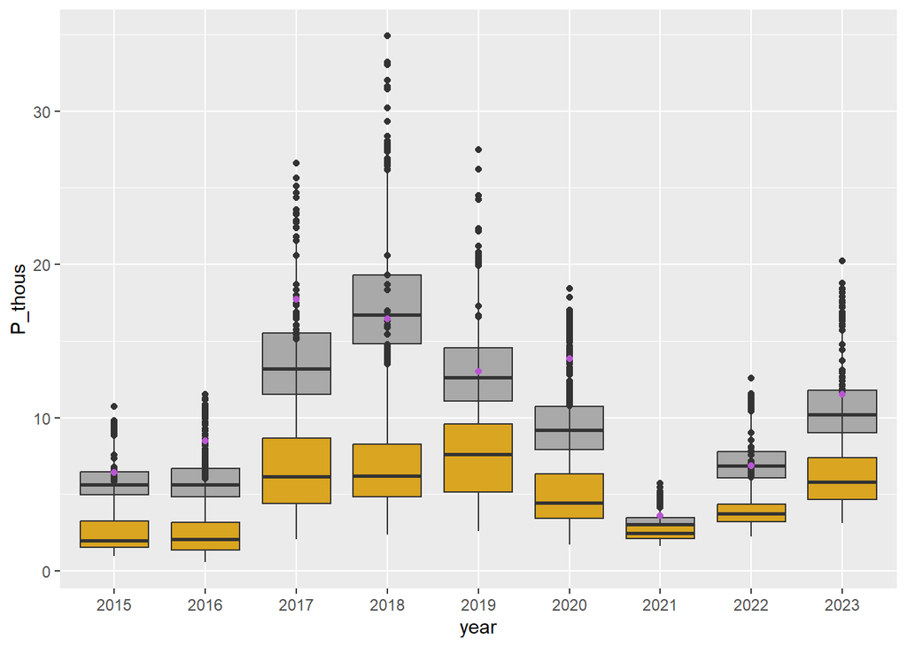

```r
# Now we replicate this function a couple thousand times, and add all the results to a dataframe.
bigdfmstormsub=suppressWarnings({ replicate(1000, subsetstormsample(owcBR_GF),simplify=FALSE)}) # supress warnings is because at one point there are some NAs it gets mad about
# combine all our dataframes together
bigdfmstormsub_combined <- map_dfr(bigdfmstormsub, bind_rows, .id = "tib")
bigdfmstormsub_combined$year = as.factor(bigdfmstormsub_combined$year)
bigdfmstormsub_combined$P_thous = bigdfmstormsub_combined$sum_P / 1000


# lets plot everything out together:
ggplot() +
  geom_boxplot(data = bigdfmstormsub_combined, aes(x=year, y=P_thous), fill = 'darkgrey') + # monthly + storm sampling
  geom_boxplot(data = bigdfm_combined, aes(x=year, y=P_thous), fill = 'goldenrod') + # monthly sampling
  geom_point(data = trueloading, aes (x=year, y=P_thous_true),color='mediumorchid') # daily sampling
```

So we see that if we only sample 5 of the biggest storms this method is definitely an improvement on monthly sampling! But depending on the year can still miss some amount of retention!

Let’s take out time and calculate some metrics of this model including the bias, the imprecision, and the relative root mean square error!

```r
bigdfmstormsub_combined = bigdfmstormsub_combined %>% left_join(y=trueloading, by=c("year")) # add the true values to the dataset so we can compute uncertainty!
bigdfmstormsub_combined$e = (bigdfmstormsub_combined$P_thous - bigdfmstormsub_combined$P_thous_true)/ bigdfmstormsub_combined$P_thous_true # calculate the error associated with each budget

dfmse = bigdfmstormsub_combined %>%
  group_by(year) %>%
  summarise(med = median(e)) # this is a measure of the Bias. Negative number indicates a consistent negative bias (here it ranges between years from -10 to -60%)
print(dfmse)
```

```
## # A tibble: 9 × 2
##   year       med
##   <fct>    <dbl>
## 1 2015  -0.124
## 2 2016  -0.338
## 3 2017  -0.254
## 4 2018   0.0182
## 5 2019  -0.0312
## 6 2020  -0.336
## 7 2021  -0.160
## 8 2022   0.00181
## 9 2023  -0.117
```

```r
mean(dfmse$med)
```

```
## [1] -0.1488555
```

```r
dfms90 = bigdfmstormsub_combined %>%
  group_by(year) %>%
  summarise("value90" = quantile(e, probs=0.9, na.rm=TRUE)) # calculate the 90th percentile for each year
dfms10 = bigdfmstormsub_combined %>%
  group_by(year) %>%
  summarise("value10" = quantile(e, probs=0.1, na.rm=TRUE)) # calculate the 10th percentile for each year
Imprecisionmdfs = dfms90 %>% left_join(y=dfms10, by=c("year")) # Merge the 90th and 10th percentile
Imprecisionmdfs$imprecision = Imprecisionmdfs$value90-Imprecisionmdfs$value10
print(Imprecisionmdfs) # values below 20% are acceptable. This indicates that there's high variation in uncertainty of our estimation.
```

```
## # A tibble: 9 × 4
##   year  value90 value10 imprecision
##   <fct>   <dbl>   <dbl>       <dbl>
## 1 2015   0.175   -0.307       0.482
## 2 2016  -0.0825  -0.497       0.415
## 3 2017   0.0140  -0.422       0.436
## 4 2018   0.393   -0.201       0.594
## 5 2019   0.268   -0.231       0.500
## 6 2020  -0.0935  -0.476       0.383
## 7 2021   0.0666  -0.323       0.390
## 8 2022   0.274   -0.195       0.469
## 9 2023   0.180   -0.299       0.479
```

```r
mean(Imprecisionmdfs$imprecision) # the average
```

```
## [1] 0.4608705
```

```r
# now to add these to our running dataframe of methodstats:
stormsubstats <- dfmse %>%
  left_join(y=Imprecisionmdfs, by=c("year"))%>% # merge the bias and imprecision data
  mutate(method = "M100_5")
stormsubstats = stormsubstats[,c("year","med","imprecision","method")] # get rid of the excess columns

methodstats = rbind(methodstats,stormsubstats) # add on to our running dataframe
```

### Variations on sampling regime

TIME to test a whole bunch of variations in how we’re measuring retention!

Things to add: Subset 1-4: 1-4 storm events sampled Subset 5-9: 1-5 storm events sampled @ 25 cfs

```r
#################################
# 1 storm event
subsetstormsample<-function (data){
  # convert to monthly sampling
  working<-owcBR_GF #create dummy data set to operate on
  working <- owcBR_GF %>%
    group_by(month,year) %>% # group by both month and year so this works across different months and across different years
    mutate(random_day = sample(daynum,1)) %>% # sample 1 random day out of the month
    mutate(TP_month = TPmgL[daynum == random_day]) %>%  # create a value for weekly TP which is the TP value for our randomly selected day
    select(-random_day) # delete our randomly selected day so a new one is chosen for each month
  working <- working %>%
    mutate(stormcon = ifelse(discharge_cfs>100, TPmgL, 'NA'))
  working$stormcon = as.numeric(working$stormcon)
  working <- working %>%
    group_by(year)%>%
    mutate(stormPav = mean(sample(working$stormcon[complete.cases(working$stormcon)],1))) # sample 5 storms and use them to compute an average stormflow concentration for the year
  working <- working %>%
    group_by(month,year)%>%
    mutate(stormPcon = ifelse(discharge_cfs>100, stormPav, TP_month)) # replace all storm values with the average storm concentration for the year
  working$P_lbs_storm = working$discharge_L * working$stormPcon / 453600 # calculate P load and convert to lbs
  working %>% # take our dataset
    group_by(year) %>% # group so we get a value for each year
    summarize(sum_P = sum(P_lbs_storm,na.rm = T)) # calculate the annual retention for each year in the dataframe
}

# Now we replicate this function a couple thousand times, and add all the results to a dataframe.
bigdfmstormsub1=suppressWarnings({ replicate(1000, subsetstormsample(owcBR_GF),simplify=FALSE)}) # supress warnings is because at one point there are some NAs it gets mad about
# combine all our dataframes together
bigdfmstormsub_combined <- map_dfr(bigdfmstormsub, bind_rows, .id = "tib")
bigdfmstormsub_combined$year = as.factor(bigdfmstormsub_combined$year)
bigdfmstormsub_combined$P_thous = bigdfmstormsub_combined$sum_P / 1000

bigdfmstormsub_combined = bigdfmstormsub_combined %>% left_join(y=trueloading, by=c("year")) # add the true values to the dataset so we can compute uncertainty!
bigdfmstormsub_combined$e = (bigdfmstormsub_combined$P_thous - bigdfmstormsub_combined$P_thous_true)/ bigdfmstormsub_combined$P_thous_true # calculate the error associated with each budget

dfmse = bigdfmstormsub_combined %>%
  group_by(year) %>%
  summarise(med = median(e)) # this is a measure of the Bias. Negative number indicates a consistent negative bias (here it ranges between years from -10 to -60%)
dfms90 = bigdfmstormsub_combined %>%
  group_by(year) %>%
  summarise("value90" = quantile(e, probs=0.9, na.rm=TRUE)) # calculate the 90th percentile for each year
dfms10 = bigdfmstormsub_combined %>%
  group_by(year) %>%
  summarise("value10" = quantile(e, probs=0.1, na.rm=TRUE)) # calculate the 10th percentile for each year
Imprecisionmdfs = dfms90 %>% left_join(y=dfms10, by=c("year")) # Merge the 90th and 10th percentile
Imprecisionmdfs$imprecision = Imprecisionmdfs$value90-Imprecisionmdfs$value10
# now to add these to our running dataframe of methodstats:
storm1stats <- dfmse %>%
  left_join(y=Imprecisionmdfs, by=c("year"))%>% # merge the bias and imprecision data
  mutate(method = "M100_1")
storm1stats = storm1stats[,c("year","med","imprecision","method")] # get rid of the excess columns
methodstats = rbind(methodstats,storm1stats) # add on to our running dataframe
#################################
# 2 storm events
subsetstormsample<-function (data){
  # convert to monthly sampling
  working<-owcBR_GF #create dummy data set to operate on
  working <- owcBR_GF %>%
    group_by(month,year) %>% # group by both month and year so this works across different months and across different years
    mutate(random_day = sample(daynum,1)) %>% # sample 1 random day out of the month
    mutate(TP_month = TPmgL[daynum == random_day]) %>%  # create a value for weekly TP which is the TP value for our randomly selected day
    select(-random_day) # delete our randomly selected day so a new one is chosen for each month
  working <- working %>%
    mutate(stormcon = ifelse(discharge_cfs>100, TPmgL, 'NA'))
  working$stormcon = as.numeric(working$stormcon)
  working <- working %>%
    group_by(year)%>%
    mutate(stormPav = mean(sample(working$stormcon[complete.cases(working$stormcon)],2))) # sample 5 storms and use them to compute an average stormflow concentration for the year
  working <- working %>%
    group_by(month,year)%>%
    mutate(stormPcon = ifelse(discharge_cfs>100, stormPav, TP_month)) # replace all storm values with the average storm concentration for the year
  working$P_lbs_storm = working$discharge_L * working$stormPcon / 453600 # calculate P load and convert to lbs
  working %>% # take our dataset
    group_by(year) %>% # group so we get a value for each year
    summarize(sum_P = sum(P_lbs_storm,na.rm = T)) # calculate the annual retention for each year in the dataframe
}

# Now we replicate this function a couple thousand times, and add all the results to a dataframe.
bigdfmstormsub=suppressWarnings({ replicate(1000, subsetstormsample(owcBR_GF),simplify=FALSE)}) # supress warnings is because at one point there are some NAs it gets mad about
# combine all our dataframes together
bigdfmstormsub_combined <- map_dfr(bigdfmstormsub, bind_rows, .id = "tib")
bigdfmstormsub_combined$year = as.factor(bigdfmstormsub_combined$year)
bigdfmstormsub_combined$P_thous = bigdfmstormsub_combined$sum_P / 1000

bigdfmstormsub_combined = bigdfmstormsub_combined %>% left_join(y=trueloading, by=c("year")) # add the true values to the dataset so we can compute uncertainty!
bigdfmstormsub_combined$e = (bigdfmstormsub_combined$P_thous - bigdfmstormsub_combined$P_thous_true)/ bigdfmstormsub_combined$P_thous_true # calculate the error associated with each budget

dfmse = bigdfmstormsub_combined %>%
  group_by(year) %>%
  summarise(med = median(e)) # this is a measure of the Bias. Negative number indicates a consistent negative bias (here it ranges between years from -10 to -60%)
dfms90 = bigdfmstormsub_combined %>%
  group_by(year) %>%
  summarise("value90" = quantile(e, probs=0.9, na.rm=TRUE)) # calculate the 90th percentile for each year
dfms10 = bigdfmstormsub_combined %>%
  group_by(year) %>%
  summarise("value10" = quantile(e, probs=0.1, na.rm=TRUE)) # calculate the 10th percentile for each year
Imprecisionmdfs = dfms90 %>% left_join(y=dfms10, by=c("year")) # Merge the 90th and 10th percentile
Imprecisionmdfs$imprecision = Imprecisionmdfs$value90-Imprecisionmdfs$value10
# now to add these to our running dataframe of methodstats:
storm2stats <- dfmse %>%
  left_join(y=Imprecisionmdfs, by=c("year"))%>% # merge the bias and imprecision data
  mutate(method = "M100_2")
storm2stats = storm2stats[,c("year","med","imprecision","method")] # get rid of the excess columns
methodstats = rbind(methodstats,storm2stats) # add on to our running dataframe
#################################
# 3 storm events
subsetstormsample<-function (data){
  # convert to monthly sampling
  working<-owcBR_GF #create dummy data set to operate on
  working <- owcBR_GF %>%
    group_by(month,year) %>% # group by both month and year so this works across different months and across different years
    mutate(random_day = sample(daynum,1)) %>% # sample 1 random day out of the month
    mutate(TP_month = TPmgL[daynum == random_day]) %>%  # create a value for weekly TP which is the TP value for our randomly selected day
    select(-random_day) # delete our randomly selected day so a new one is chosen for each month
  working <- working %>%
    mutate(stormcon = ifelse(discharge_cfs>100, TPmgL, 'NA'))
  working$stormcon = as.numeric(working$stormcon)
  working <- working %>%
    group_by(year)%>%
    mutate(stormPav = mean(sample(working$stormcon[complete.cases(working$stormcon)],3))) # sample 5 storms and use them to compute an average stormflow concentration for the year
  working <- working %>%
    group_by(month,year)%>%
    mutate(stormPcon = ifelse(discharge_cfs>100, stormPav, TP_month)) # replace all storm values with the average storm concentration for the year
  working$P_lbs_storm = working$discharge_L * working$stormPcon / 453600 # calculate P load and convert to lbs
  working %>% # take our dataset
    group_by(year) %>% # group so we get a value for each year
    summarize(sum_P = sum(P_lbs_storm,na.rm = T)) # calculate the annual retention for each year in the dataframe
}
```

```r
# Now we replicate this function a couple thousand times, and add all the results to a dataframe.
bigdfmstormsub=suppressWarnings({ replicate(1000, subsetstormsample(owcBR_GF),simplify=FALSE)}) # supress warnings is because at one point there are some NAs it gets mad about
# combine all our dataframes together
bigdfmstormsub_combined <- map_dfr(bigdfmstormsub, bind_rows, .id = "tib")
bigdfmstormsub_combined$year = as.factor(bigdfmstormsub_combined$year)
bigdfmstormsub_combined$P_thous = bigdfmstormsub_combined$sum_P / 1000

bigdfmstormsub_combined = bigdfmstormsub_combined %>% left_join(y=trueloading, by=c("year")) # add the true values to the dataset so we can compute uncertainty!
bigdfmstormsub_combined$e = (bigdfmstormsub_combined$P_thous - bigdfmstormsub_combined$P_thous_true)/ bigdfmstormsub_combined$P_thous_true # calculate the error associated with each budget

dfmse = bigdfmstormsub_combined %>%
  group_by(year) %>%
  summarise(med = median(e)) # this is a measure of the Bias. Negative number indicates a consistent negative bias (here it ranges between years from -10 to -60%)
dfms90 = bigdfmstormsub_combined %>%
  group_by(year) %>%
  summarise("value90" = quantile(e, probs=0.9, na.rm=TRUE)) # calculate the 90th percentile for each year
dfms10 = bigdfmstormsub_combined %>%
  group_by(year) %>%
  summarise("value10" = quantile(e, probs=0.1, na.rm=TRUE)) # calculate the 10th percentile for each year
Imprecisionmdfs = dfms90 %>% left_join(y=dfms10, by=c("year")) # Merge the 90th and 10th percentile
Imprecisionmdfs$imprecision = Imprecisionmdfs$value90-Imprecisionmdfs$value10
# now to add these to our running dataframe of methodstats:
storm3stats <- dfmse %>%
  left_join(y=Imprecisionmdfs, by=c("year"))%>% # merge the bias and imprecision data
  mutate(method = "M100_3")
storm3stats = storm3stats[,c("year","med","imprecision","method")] # get rid of the excess columns
methodstats = rbind(methodstats,storm3stats) # add on to our running dataframe
#################################
# 4 storm events
subsetstormsample<-function (data){
  # convert to monthly sampling
  working<-owcBR_GF #create dummy data set to operate on
  working <- owcBR_GF %>%
    group_by(month,year) %>% # group by both month and year so this works across different months and across different years
    mutate(random_day = sample(daynum,1)) %>% # sample 1 random day out of the month
    mutate(TP_month = TPmgL[daynum == random_day]) %>%  # create a value for weekly TP which is the TP value for our randomly selected day
    select(-random_day) # delete our randomly selected day so a new one is chosen for each month
  working <- working %>%
    mutate(stormcon = ifelse(discharge_cfs>100, TPmgL, 'NA'))
  working$stormcon = as.numeric(working$stormcon)
  working <- working %>%
    group_by(year)%>%
    mutate(stormPav = mean(sample(working$stormcon[complete.cases(working$stormcon)],4))) # sample 5 storms and use them to compute an average stormflow concentration for the year
  working <- working %>%
    group_by(month,year)%>%
    mutate(stormPcon = ifelse(discharge_cfs>100, stormPav, TP_month)) # replace all storm values with the average storm concentration for the year
  working$P_lbs_storm = working$discharge_L * working$stormPcon / 453600 # calculate P load and convert to lbs
  working %>% # take our dataset
    group_by(year) %>% # group so we get a value for each year
    summarize(sum_P = sum(P_lbs_storm,na.rm = T)) # calculate the annual retention for each year in the dataframe
}

# Now we replicate this function a couple thousand times, and add all the results to a dataframe.
bigdfmstormsub=suppressWarnings({ replicate(1000, subsetstormsample(owcBR_GF),simplify=FALSE)}) # supress warnings is because at one point there are some NAs it gets mad about
# combine all our dataframes together
bigdfmstormsub_combined <- map_dfr(bigdfmstormsub, bind_rows, .id = "tib")
bigdfmstormsub_combined$year = as.factor(bigdfmstormsub_combined$year)
bigdfmstormsub_combined$P_thous = bigdfmstormsub_combined$sum_P / 1000

bigdfmstormsub_combined = bigdfmstormsub_combined %>% left_join(y=trueloading, by=c("year")) # add the true values to the dataset so we can compute uncertainty!
bigdfmstormsub_combined$e = (bigdfmstormsub_combined$P_thous - bigdfmstormsub_combined$P_thous_true)/ bigdfmstormsub_combined$P_thous_true # calculate the error associated with each budget

dfmse = bigdfmstormsub_combined %>%
  group_by(year) %>%
  summarise(med = median(e)) # this is a measure of the Bias. Negative number indicates a consistent negative bias (here it ranges between years from -10 to -60%)
dfms90 = bigdfmstormsub_combined %>%
  group_by(year) %>%
  summarise("value90" = quantile(e, probs=0.9, na.rm=TRUE)) # calculate the 90th percentile for each year
dfms10 = bigdfmstormsub_combined %>%
  group_by(year) %>%
  summarise("value10" = quantile(e, probs=0.1, na.rm=TRUE)) # calculate the 10th percentile for each year
Imprecisionmdfs = dfms90 %>% left_join(y=dfms10, by=c("year")) # Merge the 90th and 10th percentile
Imprecisionmdfs$imprecision = Imprecisionmdfs$value90-Imprecisionmdfs$value10
# now to add these to our running dataframe of methodstats:
storm4stats <- dfmse %>%
  left_join(y=Imprecisionmdfs, by=c("year"))%>% # merge the bias and imprecision data
  mutate(method = "M100_4")
storm4stats = storm4stats[,c("year","med","imprecision","method")] # get rid of the excess columns
methodstats = rbind(methodstats,storm4stats) # add on to our running dataframe
#################################
# 10 storm events
subsetstormsample<-function (data){
  # convert to monthly sampling
  working<-owcBR_GF #create dummy data set to operate on
  working <- owcBR_GF %>%
    group_by(month,year) %>% # group by both month and year so this works across different months and across different years
    mutate(random_day = sample(daynum,1)) %>% # sample 1 random day out of the month
    mutate(TP_month = TPmgL[daynum == random_day]) %>%  # create a value for weekly TP which is the TP value for our randomly selected day
    select(-random_day) # delete our randomly selected day so a new one is chosen for each month
  working <- working %>%
    mutate(stormcon = ifelse(discharge_cfs>100, TPmgL, 'NA'))
  working$stormcon = as.numeric(working$stormcon)
  working <- working %>%
    group_by(year)%>%
    mutate(stormPav = mean(sample(working$stormcon[complete.cases(working$stormcon)],10))) # sample 5 storms and use them to compute an average stormflow concentration for the year
  working <- working %>%
    group_by(month,year)%>%
    mutate(stormPcon = ifelse(discharge_cfs>100, stormPav, TP_month)) # replace all storm values with the average storm concentration for the year
  working$P_lbs_storm = working$discharge_L * working$stormPcon / 453600 # calculate P load and convert to lbs
  working %>% # take our dataset
    group_by(year) %>% # group so we get a value for each year
    summarize(sum_P = sum(P_lbs_storm,na.rm = T)) # calculate the annual retention for each year in the dataframe
}
```

```r
# Now we replicate this function a couple thousand times, and add all the results to a dataframe.
bigdfmstormsub=suppressWarnings({ replicate(1000, subsetstormsample(owcBR_GF),simplify=FALSE)}) # supress warnings is because at one point there are some NAs it gets mad about
# combine all our dataframes together
bigdfmstormsub_combined <- map_dfr(bigdfmstormsub, bind_rows, .id = "tib")
bigdfmstormsub_combined$year = as.factor(bigdfmstormsub_combined$year)
bigdfmstormsub_combined$P_thous = bigdfmstormsub_combined$sum_P / 1000

bigdfmstormsub_combined = bigdfmstormsub_combined %>% left_join(y=trueloading, by=c("year")) # add the true values to the dataset so we can compute uncertainty!
bigdfmstormsub_combined$e = (bigdfmstormsub_combined$P_thous - bigdfmstormsub_combined$P_thous_true)/ bigdfmstormsub_combined$P_thous_true # calculate the error associated with each budget

dfmse = bigdfmstormsub_combined %>%
  group_by(year) %>%
  summarise(med = median(e)) # this is a measure of the Bias. Negative number indicates a consistent negative bias (here it ranges between years from -10 to -60%)
dfms90 = bigdfmstormsub_combined %>%
  group_by(year) %>%
  summarise("value90" = quantile(e, probs=0.9, na.rm=TRUE)) # calculate the 90th percentile for each year
dfms10 = bigdfmstormsub_combined %>%
  group_by(year) %>%
  summarise("value10" = quantile(e, probs=0.1, na.rm=TRUE)) # calculate the 10th percentile for each year
Imprecisionmdfs = dfms90 %>% left_join(y=dfms10, by=c("year")) # Merge the 90th and 10th percentile
Imprecisionmdfs$imprecision = Imprecisionmdfs$value90-Imprecisionmdfs$value10
# now to add these to our running dataframe of methodstats:
storm10stats <- dfmse %>%
  left_join(y=Imprecisionmdfs, by=c("year"))%>% # merge the bias and imprecision data
  mutate(method = "M100_10")
storm10stats = storm10stats[,c("year","med","imprecision","method")] # get rid of the excess columns
methodstats = rbind(methodstats,storm10stats) # add on to our running dataframe
#################################
# 1 storm event 25 cfs
subsetstormsample<-function (data){
  # convert to monthly sampling
  working<-owcBR_GF #create dummy data set to operate on
  working <- owcBR_GF %>%
    group_by(month,year) %>% # group by both month and year so this works across different months and across different years
    mutate(random_day = sample(daynum,1)) %>% # sample 1 random day out of the month
    mutate(TP_month = TPmgL[daynum == random_day]) %>%  # create a value for weekly TP which is the TP value for our randomly selected day
    select(-random_day) # delete our randomly selected day so a new one is chosen for each month
  working <- working %>%
    mutate(stormcon = ifelse(discharge_cfs>25, TPmgL, 'NA'))
  working$stormcon = as.numeric(working$stormcon)
  working <- working %>%
    group_by(year)%>%
    mutate(stormPav = mean(sample(working$stormcon[complete.cases(working$stormcon)],1))) # sample 5 storms and use them to compute an average stormflow concentration for the year
  working <- working %>%
    group_by(month,year)%>%
    mutate(stormPcon = ifelse(discharge_cfs>25, stormPav, TP_month)) # replace all storm values with the average storm concentration for the year
  working$P_lbs_storm = working$discharge_L * working$stormPcon / 453600 # calculate P load and convert to lbs
  working %>% # take our dataset
    group_by(year) %>% # group so we get a value for each year
    summarize(sum_P = sum(P_lbs_storm,na.rm = T)) # calculate the annual retention for each year in the dataframe
}

# Now we replicate this function a couple thousand times, and add all the results to a dataframe.
bigdfmstormsub=suppressWarnings({ replicate(1000, subsetstormsample(owcBR_GF),simplify=FALSE)}) # supress warnings is because at one point there are some NAs it gets mad about
# combine all our dataframes together
bigdfmstormsub_combined <- map_dfr(bigdfmstormsub, bind_rows, .id = "tib")
bigdfmstormsub_combined$year = as.factor(bigdfmstormsub_combined$year)
bigdfmstormsub_combined$P_thous = bigdfmstormsub_combined$sum_P / 1000

bigdfmstormsub_combined = bigdfmstormsub_combined %>% left_join(y=trueloading, by=c("year")) # add the true values to the dataset so we can compute uncertainty!
bigdfmstormsub_combined$e = (bigdfmstormsub_combined$P_thous - bigdfmstormsub_combined$P_thous_true)/ bigdfmstormsub_combined$P_thous_true # calculate the error associated with each budget

dfmse = bigdfmstormsub_combined %>%
  group_by(year) %>%
  summarise(med = median(e)) # this is a measure of the Bias. Negative number indicates a consistent negative bias (here it ranges between years from -10 to -60%)
dfms90 = bigdfmstormsub_combined %>%
  group_by(year) %>%
  summarise("value90" = quantile(e, probs=0.9, na.rm=TRUE)) # calculate the 90th percentile for each year
dfms10 = bigdfmstormsub_combined %>%
  group_by(year) %>%
  summarise("value10" = quantile(e, probs=0.1, na.rm=TRUE)) # calculate the 10th percentile for each year
Imprecisionmdfs = dfms90 %>% left_join(y=dfms10, by=c("year")) # Merge the 90th and 10th percentile
Imprecisionmdfs$imprecision = Imprecisionmdfs$value90-Imprecisionmdfs$value10
# now to add these to our running dataframe of methodstats:
storm1stats <- dfmse %>%
  left_join(y=Imprecisionmdfs, by=c("year"))%>% # merge the bias and imprecision data
  mutate(method = "M25_1")
storm1stats = storm1stats[,c("year","med","imprecision","method")] # get rid of the excess columns
methodstats = rbind(methodstats,storm1stats) # add on to our running dataframe
#################################
# 2 storm events 25 cfs
subsetstormsample<-function (data){
  # convert to monthly sampling
  working<-owcBR_GF #create dummy data set to operate on
  working <- owcBR_GF %>%
    group_by(month,year) %>% # group by both month and year so this works across different months and across different years
    mutate(random_day = sample(daynum,1)) %>% # sample 1 random day out of the month
    mutate(TP_month = TPmgL[daynum == random_day]) %>%  # create a value for weekly TP which is the TP value for our randomly selected day
    select(-random_day) # delete our randomly selected day so a new one is chosen for each month
  working <- working %>%
    mutate(stormcon = ifelse(discharge_cfs>25, TPmgL, 'NA'))
  working$stormcon = as.numeric(working$stormcon)
  working <- working %>%
    group_by(year)%>%
    mutate(stormPav = mean(sample(working$stormcon[complete.cases(working$stormcon)],2))) # sample 5 storms and use them to compute an average stormflow concentration for the year
  working <- working %>%
    group_by(month,year)%>%
    mutate(stormPcon = ifelse(discharge_cfs>25, stormPav, TP_month)) # replace all storm values with the average storm concentration for the year
  working$P_lbs_storm = working$discharge_L * working$stormPcon / 453600 # calculate P load and convert to lbs
  working %>% # take our dataset
    group_by(year) %>% # group so we get a value for each year
    summarize(sum_P = sum(P_lbs_storm,na.rm = T)) # calculate the annual retention for each year in the dataframe
}
```

```r
# Now we replicate this function a couple thousand times, and add all the results to a dataframe.
bigdfmstormsub=suppressWarnings({ replicate(1000, subsetstormsample(owcBR_GF),simplify=FALSE)}) # supress warnings is because at one point there are some NAs it gets mad about
# combine all our dataframes together
bigdfmstormsub_combined <- map_dfr(bigdfmstormsub, bind_rows, .id = "tib")
bigdfmstormsub_combined$year = as.factor(bigdfmstormsub_combined$year)
bigdfmstormsub_combined$P_thous = bigdfmstormsub_combined$sum_P / 1000

bigdfmstormsub_combined = bigdfmstormsub_combined %>% left_join(y=trueloading, by=c("year")) # add the true values to the dataset so we can compute uncertainty!
bigdfmstormsub_combined$e = (bigdfmstormsub_combined$P_thous - bigdfmstormsub_combined$P_thous_true)/ bigdfmstormsub_combined$P_thous_true # calculate the error associated with each budget

dfmse = bigdfmstormsub_combined %>%
  group_by(year) %>%
  summarise(med = median(e)) # this is a measure of the Bias. Negative number indicates a consistent negative bias (here it ranges between years from -10 to -60%)
dfms90 = bigdfmstormsub_combined %>%
  group_by(year) %>%
  summarise("value90" = quantile(e, probs=0.9, na.rm=TRUE)) # calculate the 90th percentile for each year
dfms10 = bigdfmstormsub_combined %>%
  group_by(year) %>%
  summarise("value10" = quantile(e, probs=0.1, na.rm=TRUE)) # calculate the 10th percentile for each year
Imprecisionmdfs = dfms90 %>% left_join(y=dfms10, by=c("year")) # Merge the 90th and 10th percentile
Imprecisionmdfs$imprecision = Imprecisionmdfs$value90-Imprecisionmdfs$value10
# now to add these to our running dataframe of methodstats:
storm2stats <- dfmse %>%
  left_join(y=Imprecisionmdfs, by=c("year"))%>% # merge the bias and imprecision data
  mutate(method = "M25_2")
storm2stats = storm2stats[,c("year","med","imprecision","method")] # get rid of the excess columns
methodstats = rbind(methodstats,storm2stats) # add on to our running dataframe
#################################
# 3 storm events 25 cfs
subsetstormsample<-function (data){
  # convert to monthly sampling
  working<-owcBR_GF #create dummy data set to operate on
  working <- owcBR_GF %>%
    group_by(month,year) %>% # group by both month and year so this works across different months and across different years
    mutate(random_day = sample(daynum,1)) %>% # sample 1 random day out of the month
    mutate(TP_month = TPmgL[daynum == random_day]) %>%  # create a value for weekly TP which is the TP value for our randomly selected day
    select(-random_day) # delete our randomly selected day so a new one is chosen for each month
  working <- working %>%
    mutate(stormcon = ifelse(discharge_cfs>25, TPmgL, 'NA'))
  working$stormcon = as.numeric(working$stormcon)
  working <- working %>%
    group_by(year)%>%
    mutate(stormPav = mean(sample(working$stormcon[complete.cases(working$stormcon)],3))) # sample 5 storms and use them to compute an average stormflow concentration for the year
  working <- working %>%
    group_by(month,year)%>%
    mutate(stormPcon = ifelse(discharge_cfs>25, stormPav, TP_month)) # replace all storm values with the average storm concentration for the year
  working$P_lbs_storm = working$discharge_L * working$stormPcon / 453600 # calculate P load and convert to lbs
  working %>% # take our dataset
    group_by(year) %>% # group so we get a value for each year
    summarize(sum_P = sum(P_lbs_storm,na.rm = T)) # calculate the annual retention for each year in the dataframe
}

# Now we replicate this function a couple thousand times, and add all the results to a dataframe.
bigdfmstormsub=suppressWarnings({ replicate(1000, subsetstormsample(owcBR_GF),simplify=FALSE)}) # supress warnings is because at one point there are some NAs it gets mad about
# combine all our dataframes together
bigdfmstormsub_combined <- map_dfr(bigdfmstormsub, bind_rows, .id = "tib")
bigdfmstormsub_combined$year = as.factor(bigdfmstormsub_combined$year)
bigdfmstormsub_combined$P_thous = bigdfmstormsub_combined$sum_P / 1000

bigdfmstormsub_combined = bigdfmstormsub_combined %>% left_join(y=trueloading, by=c("year")) # add the true values to the dataset so we can compute uncertainty!
bigdfmstormsub_combined$e = (bigdfmstormsub_combined$P_thous - bigdfmstormsub_combined$P_thous_true)/ bigdfmstormsub_combined$P_thous_true # calculate the error associated with each budget

dfmse = bigdfmstormsub_combined %>%
  group_by(year) %>%
  summarise(med = median(e)) # this is a measure of the Bias. Negative number indicates a consistent negative bias (here it ranges between years from -10 to -60%)
dfms90 = bigdfmstormsub_combined %>%
  group_by(year) %>%
  summarise("value90" = quantile(e, probs=0.9, na.rm=TRUE)) # calculate the 90th percentile for each year
dfms10 = bigdfmstormsub_combined %>%
  group_by(year) %>%
  summarise("value10" = quantile(e, probs=0.1, na.rm=TRUE)) # calculate the 10th percentile for each year
Imprecisionmdfs = dfms90 %>% left_join(y=dfms10, by=c("year")) # Merge the 90th and 10th percentile
Imprecisionmdfs$imprecision = Imprecisionmdfs$value90-Imprecisionmdfs$value10
# now to add these to our running dataframe of methodstats:
storm3stats <- dfmse %>%
  left_join(y=Imprecisionmdfs, by=c("year"))%>% # merge the bias and imprecision data
  mutate(method = "M25_3")
storm3stats = storm3stats[,c("year","med","imprecision","method")] # get rid of the excess columns
methodstats = rbind(methodstats,storm3stats) # add on to our running dataframe
#################################
# 4 storm events  25 cfs
subsetstormsample<-function (data){
  # convert to monthly sampling
  working<-owcBR_GF #create dummy data set to operate on
  working <- owcBR_GF %>%
    group_by(month,year) %>% # group by both month and year so this works across different months and across different years
    mutate(random_day = sample(daynum,1)) %>% # sample 1 random day out of the month
    mutate(TP_month = TPmgL[daynum == random_day]) %>%  # create a value for weekly TP which is the TP value for our randomly selected day
    select(-random_day) # delete our randomly selected day so a new one is chosen for each month
  working <- working %>%
    mutate(stormcon = ifelse(discharge_cfs>25, TPmgL, 'NA'))
  working$stormcon = as.numeric(working$stormcon)
  working <- working %>%
    group_by(year)%>%
    mutate(stormPav = mean(sample(working$stormcon[complete.cases(working$stormcon)],4))) # sample 5 storms and use them to compute an average stormflow concentration for the year
  working <- working %>%
    group_by(month,year)%>%
    mutate(stormPcon = ifelse(discharge_cfs>25, stormPav, TP_month)) # replace all storm values with the average storm concentration for the year
  working$P_lbs_storm = working$discharge_L * working$stormPcon / 453600 # calculate P load and convert to lbs
  working %>% # take our dataset
    group_by(year) %>% # group so we get a value for each year
    summarize(sum_P = sum(P_lbs_storm,na.rm = T)) # calculate the annual retention for each year in the dataframe
}
```

```r
# Now we replicate this function a couple thousand times, and add all the results to a dataframe.
bigdfmstormsub=suppressWarnings({ replicate(1000, subsetstormsample(owcBR_GF),simplify=FALSE)}) # supress warnings is because at one point there are some NAs it gets mad about
# combine all our dataframes together
bigdfmstormsub_combined <- map_dfr(bigdfmstormsub, bind_rows, .id = "tib")
bigdfmstormsub_combined$year = as.factor(bigdfmstormsub_combined$year)
bigdfmstormsub_combined$P_thous = bigdfmstormsub_combined$sum_P / 1000

bigdfmstormsub_combined = bigdfmstormsub_combined %>% left_join(y=trueloading, by=c("year")) # add the true values to the dataset so we can compute uncertainty!
bigdfmstormsub_combined$e = (bigdfmstormsub_combined$P_thous - bigdfmstormsub_combined$P_thous_true)/ bigdfmstormsub_combined$P_thous_true # calculate the error associated with each budget

dfmse = bigdfmstormsub_combined %>%
  group_by(year) %>%
  summarise(med = median(e)) # this is a measure of the Bias. Negative number indicates a consistent negative bias (here it ranges between years from -10 to -60%)
dfms90 = bigdfmstormsub_combined %>%
  group_by(year) %>%
  summarise("value90" = quantile(e, probs=0.9, na.rm=TRUE)) # calculate the 90th percentile for each year
dfms10 = bigdfmstormsub_combined %>%
  group_by(year) %>%
  summarise("value10" = quantile(e, probs=0.1, na.rm=TRUE)) # calculate the 10th percentile for each year
Imprecisionmdfs = dfms90 %>% left_join(y=dfms10, by=c("year")) # Merge the 90th and 10th percentile
Imprecisionmdfs$imprecision = Imprecisionmdfs$value90-Imprecisionmdfs$value10
# now to add these to our running dataframe of methodstats:
storm4stats <- dfmse %>%
  left_join(y=Imprecisionmdfs, by=c("year"))%>% # merge the bias and imprecision data
  mutate(method = "M25_4")
storm4stats = storm4stats[,c("year","med","imprecision","method")] # get rid of the excess columns
methodstats = rbind(methodstats,storm4stats) # add on to our running dataframe
#################################
# 5 storm events  25 cfs
subsetstormsample<-function (data){
  # convert to monthly sampling
  working<-owcBR_GF #create dummy data set to operate on
  working <- owcBR_GF %>%
    group_by(month,year) %>% # group by both month and year so this works across different months and across different years
    mutate(random_day = sample(daynum,1)) %>% # sample 1 random day out of the month
    mutate(TP_month = TPmgL[daynum == random_day]) %>%  # create a value for weekly TP which is the TP value for our randomly selected day
    select(-random_day) # delete our randomly selected day so a new one is chosen for each month
  working <- working %>%
    mutate(stormcon = ifelse(discharge_cfs>25, TPmgL, 'NA'))
  working$stormcon = as.numeric(working$stormcon)
  working <- working %>%
    group_by(year)%>%
    mutate(stormPav = mean(sample(working$stormcon[complete.cases(working$stormcon)],4))) # sample 5 storms and use them to compute an average stormflow concentration for the year
  working <- working %>%
    group_by(month,year)%>%
    mutate(stormPcon = ifelse(discharge_cfs>25, stormPav, TP_month)) # replace all storm values with the average storm concentration for the year
  working$P_lbs_storm = working$discharge_L * working$stormPcon / 453600 # calculate P load and convert to lbs
  working %>% # take our dataset
    group_by(year) %>% # group so we get a value for each year
    summarize(sum_P = sum(P_lbs_storm,na.rm = T)) # calculate the annual retention for each year in the dataframe
}

# Now we replicate this function a couple thousand times, and add all the results to a dataframe.
bigdfmstormsub=suppressWarnings({ replicate(1000, subsetstormsample(owcBR_GF),simplify=FALSE)}) # supress warnings is because at one point there are some NAs it gets mad about
# combine all our dataframes together
bigdfmstormsub_combined <- map_dfr(bigdfmstormsub, bind_rows, .id = "tib")
bigdfmstormsub_combined$year = as.factor(bigdfmstormsub_combined$year)
bigdfmstormsub_combined$P_thous = bigdfmstormsub_combined$sum_P / 1000

bigdfmstormsub_combined = bigdfmstormsub_combined %>% left_join(y=trueloading, by=c("year")) # add the true values to the dataset so we can compute uncertainty!
bigdfmstormsub_combined$e = (bigdfmstormsub_combined$P_thous - bigdfmstormsub_combined$P_thous_true)/ bigdfmstormsub_combined$P_thous_true # calculate the error associated with each budget

dfmse = bigdfmstormsub_combined %>%
  group_by(year) %>%
  summarise(med = median(e)) # this is a measure of the Bias. Negative number indicates a consistent negative bias (here it ranges between years from -10 to -60%)
dfms90 = bigdfmstormsub_combined %>%
  group_by(year) %>%
  summarise("value90" = quantile(e, probs=0.9, na.rm=TRUE)) # calculate the 90th percentile for each year
dfms10 = bigdfmstormsub_combined %>%
  group_by(year) %>%
  summarise("value10" = quantile(e, probs=0.1, na.rm=TRUE)) # calculate the 10th percentile for each year
Imprecisionmdfs = dfms90 %>% left_join(y=dfms10, by=c("year")) # Merge the 90th and 10th percentile
Imprecisionmdfs$imprecision = Imprecisionmdfs$value90-Imprecisionmdfs$value10
# now to add these to our running dataframe of methodstats:
storm5stats <- dfmse %>%
  left_join(y=Imprecisionmdfs, by=c("year"))%>% # merge the bias and imprecision data
  mutate(method = "M25_5")
storm5stats = storm5stats[,c("year","med","imprecision","method")] # get rid of the excess columns
methodstats = rbind(methodstats,storm5stats) # add on to our running dataframe
#################################
# 10 storm events  25 cfs
subsetstormsample<-function (data){
  # convert to monthly sampling
  working<-owcBR_GF #create dummy data set to operate on
  working <- owcBR_GF %>%
    group_by(month,year) %>% # group by both month and year so this works across different months and across different years
    mutate(random_day = sample(daynum,1)) %>% # sample 1 random day out of the month
    mutate(TP_month = TPmgL[daynum == random_day]) %>%  # create a value for weekly TP which is the TP value for our randomly selected day
    select(-random_day) # delete our randomly selected day so a new one is chosen for each month
  working <- working %>%
    mutate(stormcon = ifelse(discharge_cfs>25, TPmgL, 'NA'))
  working$stormcon = as.numeric(working$stormcon)
  working <- working %>%
    group_by(year)%>%
    mutate(stormPav = mean(sample(working$stormcon[complete.cases(working$stormcon)],10))) # sample 5 storms and use them to compute an average stormflow concentration for the year
  working <- working %>%
    group_by(month,year)%>%
    mutate(stormPcon = ifelse(discharge_cfs>25, stormPav, TP_month)) # replace all storm values with the average storm concentration for the year
  working$P_lbs_storm = working$discharge_L * working$stormPcon / 453600 # calculate P load and convert to lbs
  working %>% # take our dataset
    group_by(year) %>% # group so we get a value for each year
    summarize(sum_P = sum(P_lbs_storm,na.rm = T)) # calculate the annual retention for each year in the dataframe
}
```

```r
# Now we replicate this function a couple thousand times, and add all the results to a dataframe.
bigdfmstormsub=suppressWarnings({ replicate(1000, subsetstormsample(owcBR_GF),simplify=FALSE)}) # supress warnings is because at one point there are some NAs it gets mad about
# combine all our dataframes together
bigdfmstormsub_combined <- map_dfr(bigdfmstormsub, bind_rows, .id = "tib")
bigdfmstormsub_combined$year = as.factor(bigdfmstormsub_combined$year)
bigdfmstormsub_combined$P_thous = bigdfmstormsub_combined$sum_P / 1000

bigdfmstormsub_combined = bigdfmstormsub_combined %>% left_join(y=trueloading, by=c("year")) # add the true values to the dataset so we can compute uncertainty!
bigdfmstormsub_combined$e = (bigdfmstormsub_combined$P_thous - bigdfmstormsub_combined$P_thous_true)/ bigdfmstormsub_combined$P_thous_true # calculate the error associated with each budget

dfmse = bigdfmstormsub_combined %>%
  group_by(year) %>%
  summarise(med = median(e)) # this is a measure of the Bias. Negative number indicates a consistent negative bias (here it ranges between years from -10 to -60%)
dfms90 = bigdfmstormsub_combined %>%
  group_by(year) %>%
  summarise("value90" = quantile(e, probs=0.9, na.rm=TRUE)) # calculate the 90th percentile for each year
dfms10 = bigdfmstormsub_combined %>%
  group_by(year) %>%
  summarise("value10" = quantile(e, probs=0.1, na.rm=TRUE)) # calculate the 10th percentile for each year
Imprecisionmdfs = dfms90 %>% left_join(y=dfms10, by=c("year")) # Merge the 90th and 10th percentile
Imprecisionmdfs$imprecision = Imprecisionmdfs$value90-Imprecisionmdfs$value10
# now to add these to our running dataframe of methodstats:
storm10stats <- dfmse %>%
  left_join(y=Imprecisionmdfs, by=c("year"))%>% # merge the bias and imprecision data
  mutate(method = "M25_10")
storm10stats = storm10stats[,c("year","med","imprecision","method")] # get rid of the excess columns
methodstats = rbind(methodstats,storm10stats) # add on to our running dataframe
```

DO NOT PUT THIS SECTION FURTHER DOWN. When you add things to the owcBR_GF dataframe you screw up the code so it doesn’t work anymore.

## Lets try out some of the weird methods of gap filling! Flow-weighted means, and linear interpolation

Flow weighted means are generally calculated to get an accurate mean concentration for a highly variable wetland. It does that by weighting the values by the total water going through. It’s not that useful (as you can see in the results) for calculating loading, because loading already accounts for flow.

So what we’re doing here is taking monthly concentrations, and calculating the annual flow-weighted mean concentration. But it doesn’t improve the scale of our monthly data and get at storm events because it’s still just using the same 12 data points to calculate load.

```r
# new function calculating loading with flow-weighted mean concentrations
monthfwsample<-function (data){
  # convert to monthly sampling
  working<-data #create dummy data set to operate on
  working <- data %>%
    group_by(month,year) %>% # group by both month and year so this works across different months and across different years
    mutate(random_day = sample(daynum,1)) %>% # sample 1 random day out of the month
    mutate(TP_month = TPmgL[daynum == random_day]) %>%  # create a value for monthly TP which is the TP value for our randomly selected day
    select(-random_day)%>% # delete our randomly selected day so a new one is chosen for each month
    mutate(monthflow = sum(discharge_L))
  workmonth = working %>%
    group_by(year,month)%>%
    summarize_at(c("monthflow","TP_month"),mean)
  workmonth = workmonth%>%
    group_by(year)%>%
    mutate(cumflow = sum(monthflow))%>%
    mutate(perflow = monthflow / cumflow)%>%
    mutate(fw = perflow * TP_month)%>%
    mutate(fwmc = sum(fw))

  workmonth$P_lbs_fw = workmonth$fwmc * workmonth$monthflow / 453600 # calculate P load and convert to lbs
  workmonth %>% # take our dataset
    group_by(year) %>% # group so we get a value for each year
    summarize(sum_P = sum(P_lbs_fw,na.rm = T)) # calculate the annual retention for each year in the dataframe
}

# Now we replicate this function a couple thousand times, and add all the results to a dataframe.
bigdffw=suppressWarnings({ replicate(1000, monthfwsample(owcBR_GF),simplify=FALSE)}) # supress warnings is because at one point there are some NAs it gets mad about
# combine all our dataframes together
bigdffw_combined <- map_dfr(bigdffw, bind_rows, .id = "tib")
bigdffw_combined$year = as.factor(bigdffw_combined$year)
bigdffw_combined$P_thous = bigdffw_combined$sum_P / 1000

bigdffw_combined = bigdffw_combined %>% left_join(y=trueloading, by=c("year")) # add the true values to the dataset so we can compute uncertainty!
bigdffw_combined$e = (bigdffw_combined$P_thous - bigdffw_combined$P_thous_true)/ bigdffw_combined$P_thous_true # calculate the error associated with each budget

dfmse = bigdffw_combined %>%
  group_by(year) %>%
  summarise(med = median(e)) # this is a measure of the Bias. Negative number indicates a consistent negative bias (here it ranges between years from -10 to -60%)
dfms90 = bigdffw_combined %>%
  group_by(year) %>%
  summarise("value90" = quantile(e, probs=0.9, na.rm=TRUE)) # calculate the 90th percentile for each year
dfms10 = bigdffw_combined %>%
  group_by(year) %>%
  summarise("value10" = quantile(e, probs=0.1, na.rm=TRUE)) # calculate the 10th percentile for each year
Imprecisionmdfs = dfms90 %>% left_join(y=dfms10, by=c("year")) # Merge the 90th and 10th percentile
Imprecisionmdfs$imprecision = Imprecisionmdfs$value90-Imprecisionmdfs$value10
# now to add these to our running dataframe of methodstats:
fwmstats <- dfmse %>%
  left_join(y=Imprecisionmdfs, by=c("year"))%>% # merge the bias and imprecision data
  mutate(method = "flow-weighted")
fwmstats = fwmstats[,c("year","med","imprecision","method")] # get rid of the excess columns
methodstats = rbind(methodstats,fwmstats) # add on to our running dataframe
```

Linear interpolation: 1. Use linear interpolation function in R

```r
monthsampleint<-function (data){
  # convert to monthly sampling
  working<-data #create dummy data set to operate on
  working <- data %>%
    group_by(month,year) %>% # group by both month and year so this works across different months and across different years
    mutate(random_day = sample(daynum,1)) %>% # sample 1 random day out of the month
    mutate(TP_month_gap = ifelse(daynum == random_day, yes = TPmgL, no = "NA" )) %>% # select a random day to add to the data frame
    select(-random_day) # delete our randomly selected day so a new one is chosen for each month
  working$TP_month <- approx(working$TP_month_gap, xout=seq_along(working$Date))$y # the $y just means that we don't want the date info back. But this interpolates for us.
  working$P_lbs_week = working$discharge_L * working$TP_month / 453600 # calculate P load and convert to lbs
  working %>% # take our data set
    group_by(year) %>% # group so we get a value for each year
    summarize(sum_P = sum(P_lbs_week,na.rm = T)) # calculate the annual retention for each year in the data frame
}

monthsampleint(owcBR_GF) # here's an example of a single iteration of monthly sampling
```

```
## # A tibble: 9 × 2
##    year sum_P
##   <dbl> <dbl>
## 1  2015 1320.
## 2  2016 3707.
## 3  2017 8988.
## 4  2018 5790.
## 5  2019 7785.
## 6  2020 2721.
## 7  2021 3080.
## 8  2022 4199.
## 9  2023 5457.
```

```r
# Now we replicate this function a couple thousand times, and add all the results to a dataframe.
bigdfint=suppressWarnings({ replicate(1000, monthsampleint(owcBR_GF),simplify=FALSE)}) # supress warnings is because at one point there are some NAs it gets mad about
# combine all our dataframes together
bigdfint_combined <- map_dfr(bigdfint, bind_rows, .id = "tib")
bigdfint_combined$year = as.factor(bigdfint_combined$year)
bigdfint_combined$P_thous = bigdfint_combined$sum_P / 1000

bigdfint_combined = bigdfint_combined %>% left_join(y=trueloading, by=c("year")) # add the true values to the dataset so we can compute uncertainty!
bigdfint_combined$e = (bigdfint_combined$P_thous - bigdfint_combined$P_thous_true)/ bigdfint_combined$P_thous_true # calculate the error associated with each budget

dfmse = bigdfint_combined %>%
  group_by(year) %>%
  summarise(med = median(e)) # this is a measure of the Bias. Negative number indicates a consistent negative bias (here it ranges between years from -10 to -60%)
dfms90 = bigdfint_combined %>%
  group_by(year) %>%
  summarise("value90" = quantile(e, probs=0.9, na.rm=TRUE)) # calculate the 90th percentile for each year
dfms10 = bigdfint_combined %>%
  group_by(year) %>%
  summarise("value10" = quantile(e, probs=0.1, na.rm=TRUE)) # calculate the 10th percentile for each year
Imprecisionmdfs = dfms90 %>% left_join(y=dfms10, by=c("year")) # Merge the 90th and 10th percentile
Imprecisionmdfs$imprecision = Imprecisionmdfs$value90-Imprecisionmdfs$value10
# now to add these to our running dataframe of methodstats:
intstats <- dfmse %>%
  left_join(y=Imprecisionmdfs, by=c("year"))%>% # merge the bias and imprecision data
  mutate(method = "lin interp")
intstats = intstats[,c("year","med","imprecision","method")] # get rid of the excess columns
methodstats = rbind(methodstats,intstats) # add on to our running dataframe
```

## Lets try calculating the load leaving the wetland!

We’re going to reload the data because we want the outflow concentrations the tricky bit is figuring out what to do with measurements of discharge… the measurements taken are not consistent. We’re going to start out by assuming that discharge in = discharge out. To be clear: this is not true, especially at OWC where the lake can backflow into the wetland! They have good flow measurements but only after the period where they have consistent outflow concentrations (they changed to weekly after deciding that daily sampling was not necessary at the outlet). So first lets try and replicate why they decided that daily flow was no longer necessary at the outlets!

```r
setwd("C:/Users/kande120/OneDrive - Kent State University/Phosphorus Budgets/OWC/Data")
owcmasterdata<-read.csv("Master_Nutirent_Dataset_3-7-24.csv")
owcmasterdata$Date<-mdy(owcmasterdata$Date) # tell R that the date is a date

# now lets subset the hell out of this dataset:
owcRL <- subset(owcmasterdata, Project == "RL") # only the retention and load project
owcRLoutflow <- subset(owcRL, Site == "WM") # only the outflow at the wetland mouth
owcRLoutflowrecent <- subset(owcRLoutflow, Date >= "2015-01-01" & Date < "2019-01-01") # only from 2015 on
owcoDF = owcRLoutflowrecent %>% group_by(Site, Date = as.Date(Date,"%m/%d/%Y")) %>% summarise(across(c(TP), mean)) # average any daily TP replicates together
library(dataRetrieval)
# Old Woman Creek at Berlin Rd near Huron OH
siteNumber <- "04199155"
owcInfo <- readNWISsite(siteNumber)
parameterCd <- "00060"

# As a note they have sub-daily data, but we don't need it. We're going to be pairing with daily nutrient data so it's actually super convenient that this code makes the data daily for us!
# Raw daily data:
rawDailyData <- readNWISdv(
  siteNumber, parameterCd,
  "2015-05-05", "2024-01-01")
colnames(rawDailyData)[colnames(rawDailyData) == 'X_00060_00003'] <- 'discharge_cfs'  #rename the discharge column to something meaningful

owcoDF <- owcoDF %>%
  left_join(y=rawDailyData, by=c("Date")) # merge out 2 datasets

owcoBR = owcoDF[c("Date","TP","discharge_cfs")] # clean up our dataset so it's just our 3 variables we're interested in
owcoBR$discharge_L = owcoBR$discharge_cfs * 86400 * 28.3168 # Convert cubic feet/second to liters/day
owcoBR$TPmgL = owcoBR$TP / 1000 # convert ug/L to mg/L
owcoBR$P_lbs = owcoBR$discharge_L * owcoBR$TPmgL / 453600 # calculate P load and convert to lbs


# we're going to gap fill. It'll make everything easier in terms of coding this out
# first we need to fill in all missing dates with NAs so r doesn't get mad at us:
owcoBRcomplete = owcoBR %>%
  complete(Date = seq.Date(as.Date("2015-05-04"), max(Date), by = "1 day"))

# Now we need to define the weeks and years in our dataset so r can pick them out
owcoBRcomplete$day <- weekdays(owcoBRcomplete$Date) # Take out the day of the week
owcoBRcomplete$week<-isoweek(owcoBRcomplete$Date) # Take out the number for each isoweek.
owcoBRcomplete$year<-isoyear(owcoBRcomplete$Date) # Create a variable for each isoyear

# then we fill all the gaps with the median value (we're going to use the median for the ENTIRE DATASET)
owcoBR_GF = owcoBRcomplete %>%
  mutate_if(is.numeric, function(x) ifelse(is.na(x), median(x, na.rm = TRUE), x))
```

```r
# Now we can calculate the annual retention for each year:
trueoloading = owcoBR_GF %>%
  group_by(year = lubridate::year(Date)) %>%
  summarize(sum_P = sum(P_lbs,na.rm = T))
print(trueoloading)
```

```
## # A tibble: 4 × 2
##    year  sum_P
##   <dbl>  <dbl>
## 1  2015  4575.
## 2  2016  4784.
## 3  2017 11763.
## 4  2018 10925.
```

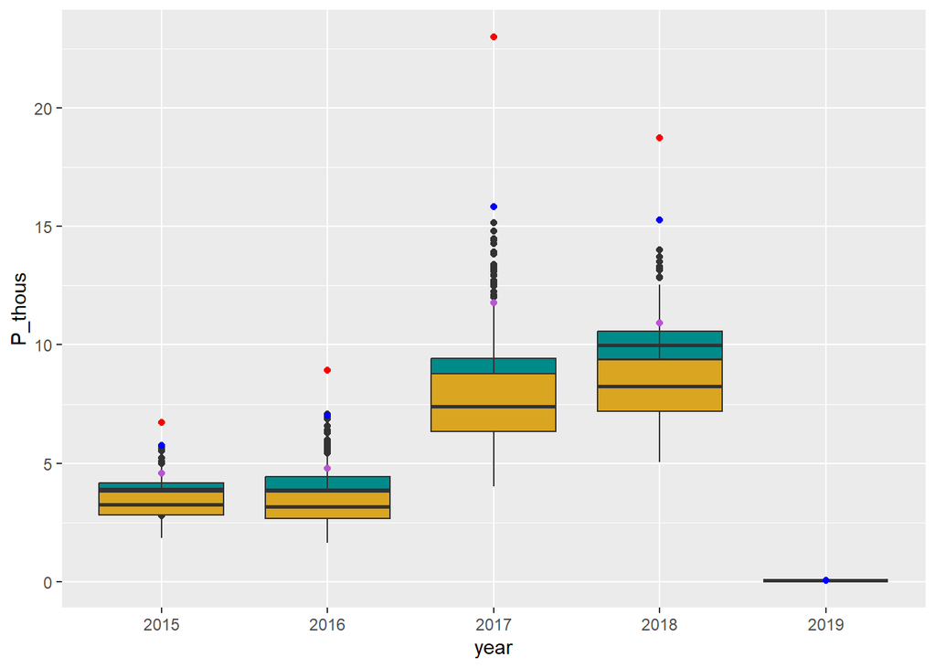

```r
# now we trasmute it into weekly sampling
bigodf=replicate(1000, weeksample(owcoBR_GF),simplify=FALSE)
# combine all our dataframes together
bigodf_combined <- map_dfr(bigodf, bind_rows, .id = "tib")
bigodf_combined$year = as.factor(bigodf_combined$year)
trueoloading$year = as.factor(trueoloading$year)
bigodf_combined$P_thous = bigodf_combined$sum_P / 1000
trueoloading$P_thous_true = trueoloading$sum_P / 1000

# calculate weekly maximums
maxovalues = maxsample(owcoBR_GF) # run the code
maxovalues$year= as.factor(maxovalues$year)

# first need to pick up the individual months:
owcoBR_GF$month<-month(owcoBRcomplete$Date) # Create a variable for each month
owcoBR_GF$daynum<-day(owcoBRcomplete$Date) # Create a variable for each day of the month
owcoBR_GF$year<-year(owcoBRcomplete$Date) # Create a variable for each year (but this time NOT iso year because that makes everything all screwy)

# trasmute to monthly sampling
bigodfm=replicate(1000, monthsample(owcoBR_GF),simplify=FALSE)
# combine all our dataframes together
bigodfm_combined <- map_dfr(bigodfm, bind_rows, .id = "tib")
bigodfm_combined$year = as.factor(bigodfm_combined$year)
trueoloading$year = as.factor(trueoloading$year)
bigodfm_combined$P_thous = bigodfm_combined$sum_P / 1000
trueoloading$P_thous_true = trueoloading$sum_P / 1000
maxovalues$P_thous = maxovalues$sum_P / 1000

# calculate monthly maximums
maxovaluesm = maxsamplem(owcoBR_GF)
maxovaluesm$P_thous = maxovaluesm$sum_P / 1000
maxovaluesm$year = as.factor(maxovaluesm$year)

# lets plot everything out together:
ggplot() +
  geom_boxplot(data = bigodf_combined, aes(x=year, y=P_thous), fill = 'darkcyan') + # weekly sampling
  geom_boxplot(data = bigodfm_combined, aes(x=year, y=P_thous), fill = 'goldenrod') + # monthly sampling
  geom_point(data = trueoloading, aes (x=year, y=P_thous_true),color='mediumorchid')+ # daily sampling
  geom_point(data = maxovalues, aes (x=year, y=P_thous),color='blue')+ # maximum values for taking the max number each WEEK
  geom_point(data = maxovaluesm, aes (x=year, y=P_thous),color='red') # maximum values for taking the max number each MONTH
```

We see that the outlet again is underestimated compared to weekly sampling, but much less so than the inlet is! There’s also a lot less variability in the range of possible values when changing sampling regime. Interesting finding there.

The difference between estimated loading at the inlet vs. outlet could lead to inaccurate retention estimates! If the underestimation is low enough you could even estimate that a wetland is releasing phosphorus when it was in fact retaining it!

Let’s take out time and calculate some metrics of this model including the bias, the imprecision, and the relative root mean square error!

```r
### Weekly outflows
bigodf_combined = bigodf_combined %>% left_join(y=trueoloading, by=c("year")) # add the true values to the dataset so we can compute uncertainty!
bigodf_combined$e = (bigodf_combined$P_thous - bigodf_combined$P_thous_true)/ bigodf_combined$P_thous_true # calculate the error associated with each budget

dfoe = bigodf_combined %>%
  group_by(year) %>%
  summarise(med = median(e)) # this is a measure of the Bias. Negative number indicates a consistent negative bias (here it ranges between years from -10 to -60%)
print(dfoe)
```

```
## # A tibble: 5 × 2
##   year      med
##   <fct>   <dbl>
## 1 2015  -0.149
## 2 2016  -0.190
## 3 2017  -0.276
## 4 2018  -0.0855
## 5 2019  NA
```

```r
mean(dfoe$med,na.rm=TRUE)
```

```
## [1] -0.1749407
```

```r
dfo90 = bigodf_combined %>%
  group_by(year) %>%
  summarise("value90" = quantile(e, probs=0.9, na.rm=TRUE)) # calculate the 90th percentile for each year
dfo10 = bigodf_combined %>%
  group_by(year) %>%
  summarise("value10" = quantile(e, probs=0.1, na.rm=TRUE)) # calculate the 10th percentile for each year
Imprecisionodf = dfo90 %>% left_join(y=dfo10, by=c("year")) # Merge the 90th and 10th percentile
Imprecisionodf$imprecision = Imprecisionodf$value90-Imprecisionodf$value10
print(Imprecisionodf) # values below 20% are acceptable. This indicates that there's high variation in uncertainty of our estimation.
```

```
## # A tibble: 5 × 4
##   year   value90 value10 imprecision
##   <fct>    <dbl>   <dbl>       <dbl>
## 1 2015  -0.0431   -0.260       0.217
## 2 2016   0.0148   -0.324       0.339
## 3 2017  -0.131    -0.390       0.259
## 4 2018   0.00653  -0.186       0.193
## 5 2019  NA        NA          NA
```

```r
mean(Imprecisionodf$imprecision,na.rm=TRUE) # the average
```

```
## [1] 0.25212
```

```r
# now to add these to our running dataframe of methodstats:
outweekstats <- dfoe %>%
  left_join(y=Imprecisionodf, by=c("year"))%>% # merge the bias and imprecision data
  mutate(method = "week out")
outweekstats = outweekstats[,c("year","med","imprecision","method")] # get rid of the excess columns
outweekstats = subset(outweekstats, year != "2019") # get rid of 2019 because it has no data

methodstats = rbind(methodstats,outweekstats) # add on to our running dataframe



### Monthly outflows
bigodfm_combined = bigodfm_combined %>% left_join(y=trueoloading, by=c("year")) # add the true values to the dataset so we can compute uncertainty!
bigodfm_combined$e = (bigodfm_combined$P_thous - bigodfm_combined$P_thous_true)/ bigodfm_combined$P_thous_true # calculate the error associated with each budget

dfome = bigodfm_combined %>%
  group_by(year) %>%
  summarise(med = median(e)) # this is a measure of the Bias. Negative number indicates a consistent negative bias (here it ranges between years from -10 to -60%)
print(dfome)
```

```
## # A tibble: 4 × 2
##   year     med
##   <fct>  <dbl>
## 1 2015  -0.291
## 2 2016  -0.340
## 3 2017  -0.371
## 4 2018  -0.245
```

```r
mean(dfome$med)
```

```
## [1] -0.311785
```

```r
dfmo90 = bigodfm_combined %>%
  group_by(year) %>%
  summarise("value90" = quantile(e, probs=0.9, na.rm=TRUE)) # calculate the 90th percentile for each year
dfmo10 = bigodfm_combined %>%
  group_by(year) %>%
  summarise("value10" = quantile(e, probs=0.1, na.rm=TRUE)) # calculate the 10th percentile for each year
Imprecisionmodf = dfmo90 %>% left_join(y=dfmo10, by=c("year")) # Merge the 90th and 10th percentile
Imprecisionmodf$imprecision = Imprecisionmodf$value90-Imprecisionmodf$value10
print(Imprecisionmodf) # values below 20% are acceptable. This indicates that there's high variation in uncertainty of our estimation.
```

```
## # A tibble: 4 × 4
##   year  value90 value10 imprecision
##   <fct>   <dbl>   <dbl>       <dbl>
## 1 2015  -0.0811  -0.443       0.362
## 2 2016  -0.0626  -0.509       0.447
## 3 2017  -0.118   -0.522       0.404
## 4 2018  -0.0467  -0.410       0.363
```

```r
mean(Imprecisionmodf$imprecision) # the average
```

```
## [1] 0.393881
```

```r
# now to add these to our running dataframe of methodstats:
outmonthstats <- dfome %>%
  left_join(y=Imprecisionmodf, by=c("year"))%>% # merge the bias and imprecision data
  mutate(method = "monthly out")
outmonthstats = outmonthstats[,c("year","med","imprecision","method")] # get rid of the excess columns

methodstats = rbind(methodstats,outmonthstats) # add on to our running dataframe
```

## Now lets try to combine these! Now we can actually measure retention!

We’re again going to assume that the discharge in = discharge out. We’re specifically focused on phosphorus sampling and how variation in phosphorus can affect estimates of retention so FOR NOW we’re going to let the discharge be innacurate leaving the wetland.

```r
setwd("C:/Users/kande120/OneDrive - Kent State University/Phosphorus Budgets/OWC/Data")
owcmasterdata<-read.csv("Master_Nutirent_Dataset_3-7-24.csv")
owcmasterdata$Date<-mdy(owcmasterdata$Date) # tell R that the date is a date

# now lets subset the hell out of this dataset:
owcRL <- subset(owcmasterdata, Project == "RL") # only the retention and load project

owcRLrecent <- subset(owcRL, Date >= "2015-01-01" & Date < "2019-01-01") # only from 2015 to 2019 when they stopped measuring daily
owcDF = owcRLrecent %>% group_by(Site, Date = as.Date(Date,"%m/%d/%Y")) %>% summarise(across(c(TP), mean)) # average any daily TP replicates together
owcDFnew = owcDF %>%
    pivot_wider(names_from = Site, values_from = TP)
owcDFnew = owcDFnew %>%
  rename(TPin = BR,TPout = WM)

library(dataRetrieval)
# Old Woman Creek at Berlin Rd near Huron OH
siteNumber <- "04199155"
owcInfo <- readNWISsite(siteNumber)
parameterCd <- "00060"

# As a note they have sub-daily data, but we don't need it. We're going to be pairing with daily nutrient data so it's actually super convenient that this code makes the data daily for us!
# Raw daily data:
rawDailyData <- readNWISdv(
  siteNumber, parameterCd,
  "2015-05-05", "2024-01-01")
colnames(rawDailyData)[colnames(rawDailyData) == 'X_00060_00003'] <- 'discharge_cfs'  #rename the discharge column to something meaningful

owcDFfull <- owcDFnew %>%
  left_join(y=rawDailyData, by=c("Date")) # merge out 2 datasets

owcBRfull = owcDFfull[c("Date","TPin","TPout","discharge_cfs")] # clean up our dataset so it's just our 3 variables we're interested in
owcBRfull$discharge_L = owcBRfull$discharge_cfs * 86400 * 28.3168 # Convert cubic feet/second to liters/day
owcBRfull$TPinmgL = owcBRfull$TPin / 1000 # convert ug/L to mg/L
owcBRfull$TPoutmgL = owcBRfull$TPout / 1000 # convert ug/L to mg/L
owcBRfull$P_lbsin = owcBRfull$discharge_L * owcBRfull$TPinmgL / 453600 # calculate P load and convert to lbs
owcBRfull$P_lbsout = owcBRfull$discharge_L * owcBRfull$TPoutmgL / 453600 # calculate P load and convert to lbs

# we're going to gap fill. It'll make everything easier in terms of coding this out
# first we need to fill in all missing dates with NAs so r doesn't get mad at us:
owcBRfullcomplete = owcBRfull %>%
  complete(Date = seq.Date(as.Date("2015-05-04"), max(Date), by = "1 day"))

# Now we need to define the weeks and years in our dataset so r can pick them out
owcBRfullcomplete$day <- weekdays(owcBRfullcomplete$Date) # Take out the day of the week
owcBRfullcomplete$week<-isoweek(owcBRfullcomplete$Date) # Take out the number for each isoweek.
owcBRfullcomplete$year<-isoyear(owcBRfullcomplete$Date) # Create a variable for each isoyear

# then we fill all the gaps with the median value (we're going to use the median for the ENTIRE DATASET)
owcBRfull_GF = owcBRfullcomplete %>%
  mutate_if(is.numeric, function(x) ifelse(is.na(x), median(x, na.rm = TRUE), x))


# Now we can calculate the annual retention for each year:
trueretention = owcBRfull_GF %>%
  group_by(year = lubridate::year(Date)) %>%
  summarize(sum_P = sum((P_lbsin-P_lbsout),na.rm = T))
print(trueretention)
```

```
## # A tibble: 4 × 2
##    year sum_P
##   <dbl> <dbl>
## 1  2015 1825.
## 2  2016 3702.
## 3  2017 5948.
## 4  2018 5506.
```

Now we need to remake our algorithms so they calculate retention instead of loading.

```r
# first we make a function to translate our dataset from daily to weekly sampling with a random selection of days being chosen! Then calculate the annual retention for each year within the dataset
weekretensample<-function (data){
  # convert to weekly sampling
  working<-data #create dummy data set to operate on
  working <- data %>%
    group_by(week,year) %>% # group by both week and year so this works across different weeks and across different years
    mutate(random_day = sample(day,1)) %>% # sample 1 random day out of the week
    mutate(TPin_week = TPinmgL[day == random_day]) %>%  # create a value for weekly TP which is the TP value for our randomly selected day
    mutate(TPout_week = TPoutmgL[day == random_day]) %>%  # create a value for weekly TP which is the TP value for our randomly selected day
    select(-random_day) # delete our randomly selected day so a new one is chosen for each week
  working$P_lbsin_week = working$discharge_L * working$TPin_week / 453600 # calculate P load and convert to lbs
  working$P_lbsout_week = working$discharge_L * working$TPout_week / 453600 # calculate P load and convert to lbs
  working$Preten_week = (working$P_lbsin_week - working$P_lbsout_week)
  working %>% # take our dataset
    group_by(year) %>% # group so we get a value for each year
    summarize(sum_P = sum(Preten_week,na.rm = T)) # calculate the annual retention for each year in the dataframe
}

weekretensample(owcBRfull_GF) # here's an example of a single iteration of weekly sampling
```

```
## # A tibble: 5 × 2
##    year    sum_P
##   <dbl>    <dbl>
## 1  2015 -1535.
## 2  2016  1625.
## 3  2017  1401.
## 4  2018 -2542.
## 5  2019    -8.04
```

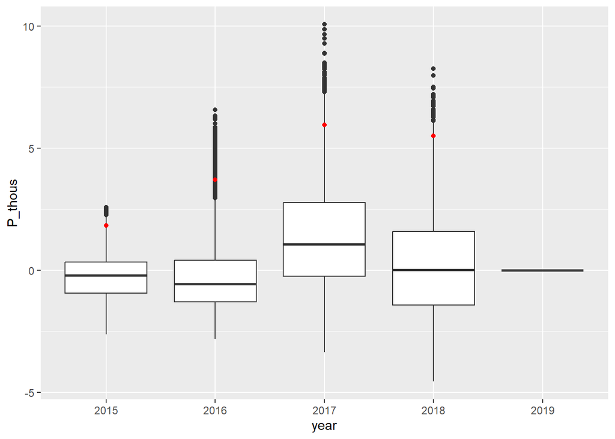

```r
# Now we replicate this function a couple thousand times, and add all the results to a dataframe.
bigdfr=replicate(10000, weekretensample(owcBRfull_GF),simplify=FALSE)
# combine all our dataframes together
bigdfr_combined <- map_dfr(bigdfr, bind_rows, .id = "tib")
bigdfr_combined$year = as.factor(bigdfr_combined$year)
trueretention$year = as.factor(trueretention$year)
bigdfr_combined$P_thous = bigdfr_combined$sum_P / 1000
trueretention$P_thous_true = trueretention$sum_P / 1000
# lets plot it out:
ggplot() +
  geom_boxplot(data = bigdfr_combined, aes(x=year, y=P_thous)) +
  geom_point(data = trueretention, aes (x=year, y=P_thous_true),color='red')
```

Let’s highlight this using our Bias and Imprecision values for each method at the inflow vs. outflow.

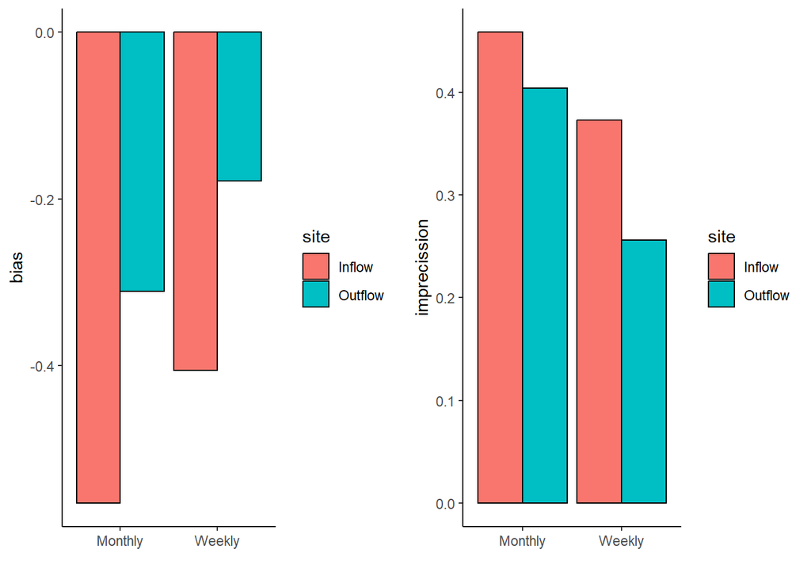

```r
method <- c('Weekly','Weekly','Monthly','Monthly')
site <- c('Inflow','Outflow','Inflow','Outflow')
bias <- c(-0.405314, -0.1785602, -0.5644752, -0.3110493)
imprecission <- c(0.3728673, 0.2560827, 0.4588433, 0.4045302)
metrics = data.frame(method,site,bias,imprecission)
# plot it out
pbias <- ggplot(data=metrics, aes(x=method, y=bias, fill=site)) +xlab("")+
geom_bar(stat="identity", color="black", position=position_dodge())+
  theme_classic()
pimprec <- ggplot(data=metrics, aes(x=method, y=imprecission, fill=site)) +
geom_bar(stat="identity", color="black", position=position_dodge())+xlab("")+
  theme_classic()
ggarrange(pbias,pimprec)
```

### Adding real discharge data

So lets see how this changes with REAL outflow data (weekly baseflow concentrations and daily for all storm events >25 cfs)

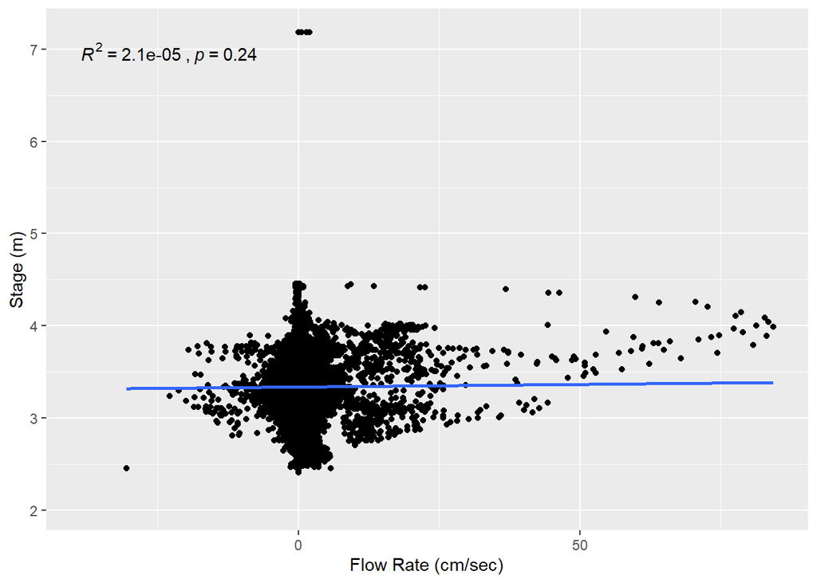

```r
setwd("C:/Users/kande120/OneDrive - Kent State University/Phosphorus Budgets/OWC/Data")
owcoutflow<-read.csv("WM Water Level and Flow Master Dataset_03-01-2024.csv")
owcoutflow$Date<-mdy(owcoutflow$Date) # tell R that the date is a date

ggplot(owcoutflow, aes(x=FlowRate_cms, y=Corrected.Stage_meters)) +
  geom_point() +
  xlab("Flow Rate (cm/sec)") + ylab("Stage (m)")+
  stat_cor(method = "pearson",aes(label = paste(..rr.label.., ..p.label.., sep = "~`,`~")))+ geom_smooth(method=lm, se=FALSE, fullrange=F)
```

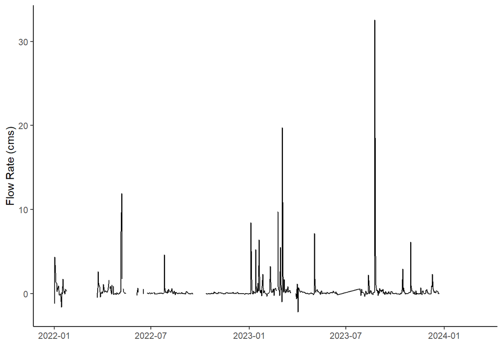

```r
# calculate the daily flow rate:
owcout = owcoutflow %>% group_by(Date = as.Date(Date,"%m/%d/%Y")) %>% summarise(across(c(FlowRate_cms), mean)) # sum all daily discharge together
owcout <- subset(owcout, Date >= "2022-01-01") # only from 2023

ggplot(owcout, aes(x=Date, y=FlowRate_cms)) +
  geom_line() +
  xlab("") + ylab("Flow Rate (cms)")+theme_classic()
```

There’s not a clear relationship between flow rate and stage.  
I think that makes a lot of sense given that stage is going to be affected in the same direction both by the lake and by the river, and flow will be affected in opposite directions…  
OWC may not be the best location to estimate differences between inflows and outflows, because the outflow is so weird… BUT maybe the story is just that the outflow concentration matters because it is more stable (because that’s what wetlands do).  
So lets build out the weekly + storm sampling to extend the baseflow and see how our bias looks in a couple different configurations of the data!

```r
# resubset the nutrient dataset:
owcRL23 <- subset(owcRL, Date >= "2023-01-01" & Date < "2024-01-01") # only from 2023

owcDF23 = owcRL23 %>% group_by(Site, Date = as.Date(Date,"%m/%d/%Y")) %>% summarise(across(c(TP), mean)) # average any daily TP replicates together
owcDF23new = owcDF23 %>%
    pivot_wider(names_from = Site, values_from = TP)
owcDF23new = owcDF23new %>%
  rename(TPin = BR,TPout = WM)

owcDF23full <- owcDF23new %>%
  left_join(y=owcout, by=c("Date")) # merge out 2 datasets

owcDF23full$outflow_Ls = owcDF23full$FlowRate_cms*1000
owcDF23full$outflow_L = owcDF23full$outflow_Ls*86400
owcDF23full$P_lbsout = (owcDF23full$outflow_L*(owcDF23full$TPout/1000)) / 453600 # convert ug/L to mg/L and convert to lbs

owcDF23full$month<-month(owcDF23full$Date) # Create a variable for each month


# gap fill with the median for TP and discharge
owcDF23final = owcDF23full %>%
  group_by(month) %>%
  mutate_if(is.numeric, function(x) ifelse(is.na(x), median(x, na.rm = TRUE), x))
```

```
## `mutate_if()` ignored the following grouping variables:
## • Column `month`
```

```r
# Now we can calculate the annual retention for each year:
outloading = owcDF23final %>%
  group_by(month = lubridate::month(Date)) %>%
  summarize(sum_P = sum(P_lbsout,na.rm = T))
print(outloading)
```

```
## # A tibble: 12 × 2
##    month  sum_P
##    <dbl>  <dbl>
##  1     1  403.
##  2     2  302.
##  3     3 3164.
##  4     4  234.
##  5     5   87.1
##  6     6  119.
##  7     7  112.
##  8     8  407.
##  9     9   77.1
## 10    10  710.
## 11    11   57.3
## 12    12  411.
```

```r
Pin23 = 11539
Pout23 = sum(outloading$sum_P)
reten23 = Pin23 - Pout23
print(reten23)
```

```
## [1] 5454.174
```

What we see is that the outlet of the wetland has higher concentrations of P, but less variability in concentration.

Now we can calculate and look at the bias at the outlet for 2023:

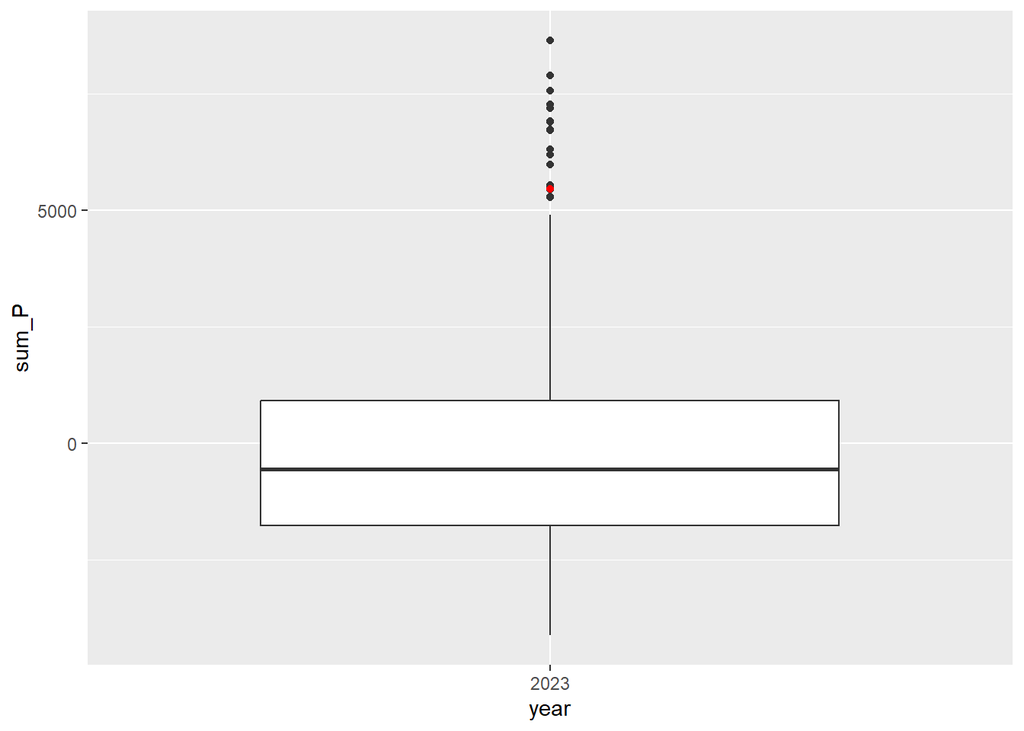

```r
# first we need to make a dataframe with inflow concentrations, outflow concentrations, inflowing water, and outflowing water
discharge23 = subset(owcBR_GF, year == "2023")
dis23 = data.frame(discharge23$discharge_L, discharge23$Date)
colnames(dis23) = c("inflow_L","Date") # chance the column names
# merge together
owc23 <- owcDF23final %>%
  left_join(y=dis23, by=c("Date")) # merge our 2 datasets
owc23$TPinmgL = owc23$TPin / 1000
owc23$TPoutmgL = owc23$TPout / 1000
owc23$year = as.factor("2023")
owc23$month = as.factor(owc23$month)
owc23$daynum<-day(owc23$Date) # Create a variable for each day of the month


# make our algorithm
monthretensample<-function (data){
  # convert to weekly sampling
  working<-data #create dummy data set to operate on
  working <- data %>%
    group_by(month,year) %>% # group by both month and year so this works across different months and across different years
    mutate(random_day = sample(daynum,1)) %>% # sample 1 random day out of the month
    mutate(TPin_month = TPinmgL[daynum == random_day]) %>%  # create a value for monthly TP which is the TP value for our randomly selected day
    mutate(TPout_month = TPoutmgL[daynum == random_day]) %>%  # create a value for monthly TP which is the TP value for our randomly selected day
    select(-random_day) # delete our randomly selected day so a new one is chosen for each week
  working$P_lbsin_month = working$inflow_L * working$TPin_month / 453600 # calculate P load and convert to lbs
  working$P_lbsout_month = working$outflow_L * working$TPout_month / 453600 # calculate P load and convert to lbs
  working$Preten_month = (working$P_lbsin_month - working$P_lbsout_month)
  working %>% # take our dataset
    group_by(year) %>% # group so we get a value for each year
    summarize(sum_P = sum(Preten_month,na.rm = T)) # calculate the annual retention for each year in the dataframe
}


# Now we replicate this function a couple thousand times, and add all the results to a dataframe.
bigdfr=replicate(1000, monthretensample(owc23),simplify=FALSE)
# combine all our dataframes together
bigdfr_combined <- map_dfr(bigdfr, bind_rows, .id = "tib")
bigdfr_combined$year = as.factor(bigdfr_combined$year)

# lets plot it out:
ggplot() +
  geom_boxplot(data = bigdfr_combined, aes(x=year, y=sum_P)) +
  geom_point(aes (x="2023", y=5454.174),color='red')
```

CLEARLY ILLUSTRATES THE PROBLEM!! This time with REAL DATA!!  
Let’s calculate biases just to be safe:

```r
bigdfr_combined$true_reten = 5454.174
bigdfr_combined$e = (bigdfr_combined$sum_P - bigdfr_combined$true_reten)/ bigdfr_combined$true_reten # calculate the error associated with each budget


dfmse = bigdfr_combined %>%
  group_by(year) %>%
  summarise(med = median(e)) # this is a measure of the Bias. Negative number indicates a consistent negative bias (here it ranges between years from -10 to -60%)
dfms90 = bigdfr_combined %>%
  group_by(year) %>%
  summarise("value90" = quantile(e, probs=0.9, na.rm=TRUE)) # calculate the 90th percentile for each year
dfms10 = bigdfr_combined %>%
  group_by(year) %>%
  summarise("value10" = quantile(e, probs=0.1, na.rm=TRUE)) # calculate the 10th percentile for each year
Imprecisionmdfs = dfms90 %>% left_join(y=dfms10, by=c("year")) # Merge the 90th and 10th percentile
Imprecisionmdfs$imprecision = Imprecisionmdfs$value90-Imprecisionmdfs$value10
dfmse
```

```
## # A tibble: 1 × 2
##   year    med
##   <fct> <dbl>
## 1 2023  -1.10
```

```r
Imprecisionmdfs
```

```
## # A tibble: 1 × 4
##   year  value90 value10 imprecision
##   <fct>   <dbl>   <dbl>       <dbl>
## 1 2023   -0.517   -1.44       0.921
```

### Lets compare our various methods against each other to see how they do:

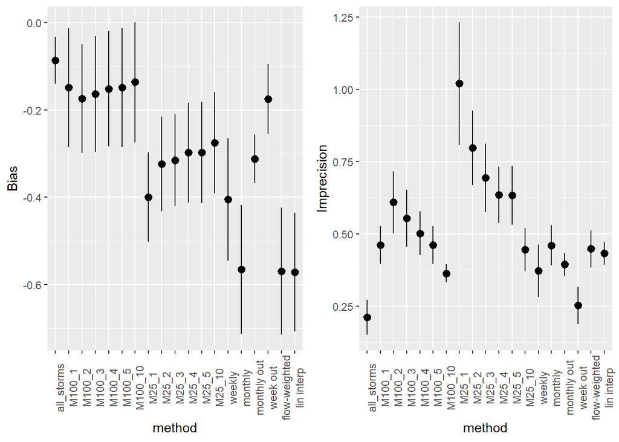

```r
# Summarize our data
grouped <- group_by(methodstats, method)
dfbias=summarise(grouped, medi=mean(med), sd=sd(med))

# plot bias
dfbias$method = factor(dfbias$method, ordered = TRUE,
                       levels = c("all_storms", "M100_1", "M100_2", "M100_3", "M100_4", "M100_5", "M100_10", "M25_1", "M25_2", "M25_3", "M25_4", "M25_5","M25_10", "weekly","monthly","monthly out","week out", "flow-weighted","lin interp"))
pbias = ggplot(dfbias, aes(x=method, y=medi)) +
  geom_pointrange(aes(ymin=medi-sd, ymax=medi+sd))+ylab("Bias")+ theme(axis.text.x = element_text(angle=90))

# now for imprecision
grouped <- group_by(methodstats, method)
dfimp =summarise(grouped, imp=mean(imprecision), sd=sd(imprecision))

dfimp$method = factor(dfimp$method, ordered = TRUE,
                      levels = c("all_storms", "M100_1", "M100_2", "M100_3", "M100_4", "M100_5", "M100_10", "M25_1", "M25_2", "M25_3", "M25_4", "M25_5","M25_10", "weekly","monthly","monthly out","week out", "flow-weighted","lin interp"))
# plot imprecision
pimp = ggplot(dfimp, aes(x=method, y=imp)) +
  geom_pointrange(aes(ymin=imp-sd, ymax=imp+sd))+ylab("Imprecision")+ theme(axis.text.x = element_text(angle=90))

ggarrange(pbias, pimp)
```

Each year is used as a different replicate to calculate the standard deviation for this plot, whereas the error (and bias and imprecision) is calculated using the 1,000-10,000 replicate samples.

Here bias refers the the extent to which the estimates are different from the true values, whereas imprecision refers to the variability within estimates. Bias is the median error value for each year from the 1,000 - 10,000 replicates. Imprecision is the mean of the 90th percentile minus the 10th percentile of error for each replicate.